# Population size

Justine Floret

2024-07-09

## Library and Data preparation

```r
library(readr)
library(dplyr)
library(tidyr)
library(tidyverse)
library(reshape2) #melt function
library(forcats) #reorganise in geom boxplot
library(kableExtra) # Markdown table

# Stat library
# library(lme4)
library(lmerTest) #glht
# library(MASS)
library(lsmeans) #pairwise comparison
library(multcomp)  #glht
library(multcompView)  #glht
library(rstatix) # manova levene test
library(car) # anova

# Graphic library
library(GGally) #ppair plot
library(ggplot2)
library(viridis)
library(svglite) # save in svg format
library(corrplot)


setwd("/home/justine/sciebo/1_Populations/3_runs")

data_all <- read_csv("/home/justine/sciebo/1_Populations/2_assay/dataset/Phenology_field.csv")

data_all$Site_ID <- as.factor(data_all$Site_ID)
data_all$Area <- as.factor(data_all$Area)
data_all$Localization_ID <- as.factor(data_all$Localization_ID)
data_all$Type <- as.factor(data_all$Type)
data_all$Destroyed <- as.factor(data_all$Destroyed)
data_all$Outliers_soil <- as.factor(data_all$Outliers_soil)
data_all$Sowing_1st <- as.factor(data_all$Sowing_1st)
data_all$Sowing_2nd <- as.factor(data_all$Sowing_2nd)
data_all$Germ_2ndyear <- as.factor(data_all$Germ_2ndyear)
data_all$Presence_April_22 <- as.factor(data_all$Presence_April_22)
data_all$Presence_April_23 <- as.factor(data_all$Presence_April_23)
data_all$Presence_April_24 <- as.factor(data_all$Presence_April_24)
```

For all the analysis the sites with no established population are removed.

## April 2022

Kept the site destroyed after April 2022

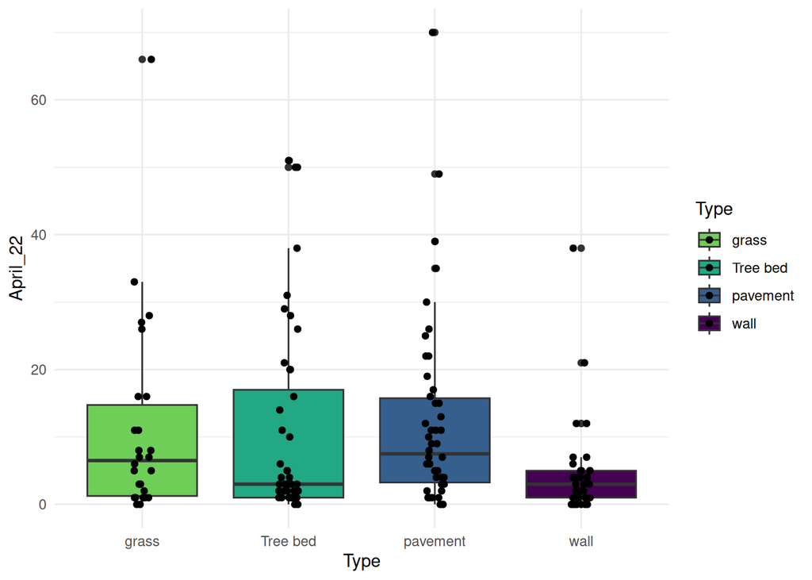

```r
# colors <- c("#6a176e","#bc3754", "#f37819", "#f8cd37")
# colors <- c("#420a68","#932667", "#dd513a", "#fca50a")
# colors <- c("#3b0f70","#8c2981", "#de4968", "#fe9f6d")
colors <- c("#6ece58",  "#22a884", "#355f8d", "#440154")


data_all %>% dplyr::filter(Destroyed == "Exist" | Destroyed =="05/2022" | Destroyed =="09/2022" | Destroyed =="10/2022" | Destroyed =="04/2023"| Destroyed =="04/2024") %>% dplyr::filter(Sowing_1st =="09/2021") %>% dplyr::filter(Presence_April_22 =="Yes") %>%
  mutate(Type = fct_relevel(Type,
            "grass", "Tree bed", "pavement", "wall")) %>%
  ggplot(aes(x = Type, y= April_22, fill = Type)) + geom_boxplot() + geom_point(position = position_jitterdodge())+
  theme_minimal() + scale_discrete_manual(aesthetics = "fill", values =colors)
```

```r
#ggsave("/home/justine/sciebo/Paper_urban_niche/Figures/Population_size_April22.svg", plot = last_plot(),dpi = 900, device = "svg", bg = "transparent")
```

#### model

```r
April22_popsize <- data_all %>% dplyr::filter(Destroyed == "Exist" | Destroyed =="05/2022" | Destroyed =="09/2022" | Destroyed =="10/2022" | Destroyed =="04/2023"| Destroyed =="04/2024") %>%  dplyr::filter(Sowing_1st =="09/2021") %>% dplyr::filter(Presence_April_22 =="Yes")

mod5 <- MASS::glm.nb(April_22 ~ Type, data = April22_popsize)

mod6 <- glm(April_22 ~ Type, data = April22_popsize ,family=negative.binomial(theta=mod5[["theta"]]))
summary(mod6)
```

```
##
## Call:
## glm(formula = April_22 ~ Type, family = negative.binomial(theta = mod5[["theta"]]),
##     data = April22_popsize)
##
## Coefficients:
##              Estimate Std. Error t value Pr(>|t|)
## (Intercept)   2.42208    0.25736   9.411   <2e-16 ***
## Typepavement  0.08788    0.32167   0.273   0.7851
## TypeTree bed -0.03457    0.32475  -0.106   0.9154
## Typewall     -0.88760    0.34412  -2.579   0.0109 *
## ---
## Signif. codes:  0 '***' 0.001 '**' 0.01 '*' 0.05 '.' 0.1 ' ' 1
##
## (Dispersion parameter for Negative Binomial(0.7647) family taken to be 1.233255)
##
##     Null deviance: 185.14  on 151  degrees of freedom
## Residual deviance: 171.54  on 148  degrees of freedom
## AIC: 1001.3
##
## Number of Fisher Scoring iterations: 6
```

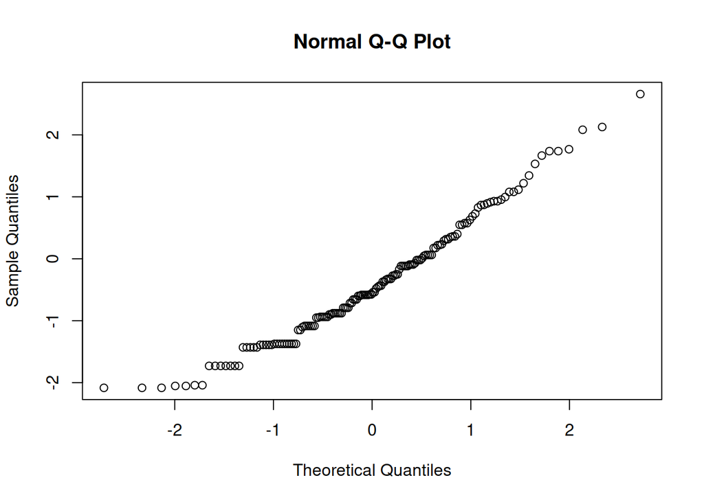

```r
qqnorm(resid(mod6))
```

```r
car::Anova(mod6)
```

```
## Analysis of Deviance Table (Type II tests)
##
## Response: April_22
##      LR Chisq Df Pr(>Chisq)
## Type   11.032  3    0.01155 *
## ---
## Signif. codes:  0 '***' 0.001 '**' 0.01 '*' 0.05 '.' 0.1 ' ' 1
```

```r
car::Anova(mod6, test.statistic="F")
```

```
## Analysis of Deviance Table (Type II tests)
##
## Response: April_22
## Error estimate based on Pearson residuals
##
##            Sum Sq  Df F value  Pr(>F)
## Type       13.606   3  3.6775 0.01361 *
## Residuals 182.522 148
## ---
## Signif. codes:  0 '***' 0.001 '**' 0.01 '*' 0.05 '.' 0.1 ' ' 1
```

```r
summary(glht(mod6 , mcp(Type="Tukey")))
```

```
##
##   Simultaneous Tests for General Linear Hypotheses
##
## Multiple Comparisons of Means: Tukey Contrasts
##
##
## Fit: glm(formula = April_22 ~ Type, family = negative.binomial(theta = mod5[["theta"]]),
##     data = April22_popsize)
##
## Linear Hypotheses:
##                          Estimate Std. Error z value Pr(>|z|)
## pavement - grass == 0     0.08788    0.32167   0.273  0.99283
## Tree bed - grass == 0    -0.03457    0.32475  -0.106  0.99957
## wall - grass == 0        -0.88760    0.34412  -2.579  0.04823 *
## Tree bed - pavement == 0 -0.12244    0.27652  -0.443  0.97083
## wall - pavement == 0     -0.97548    0.29903  -3.262  0.00614 **
## wall - Tree bed == 0     -0.85304    0.30234  -2.821  0.02457 *
## ---
## Signif. codes:  0 '***' 0.001 '**' 0.01 '*' 0.05 '.' 0.1 ' ' 1
## (Adjusted p values reported -- single-step method)
```

## April 2023

Kept the site destroyed after April 2023

### Sowing 2021

I removed the sites sown a second time with 10 000 seeds in July 2022

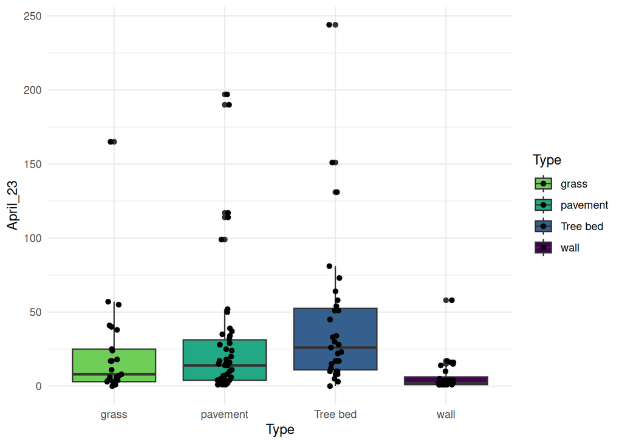

```r
data_all %>% dplyr::filter(Destroyed == "Exist"| Destroyed =="04/2024") %>%  dplyr::filter(Sowing_1st =="09/2021") %>% dplyr::filter(Sowing_2nd =="no") %>%  dplyr::filter(Presence_April_23 =="Yes") %>%
  ggplot(aes(x = Type, y= April_23, fill = Type)) + geom_boxplot() + geom_point(position = position_jitterdodge())+
  theme_minimal() + scale_discrete_manual(aesthetics = "fill", values =colors)
```

#### model

```r
April23_popsize <- data_all %>% dplyr::filter(Destroyed == "Exist"| Destroyed =="04/2024") %>%
  dplyr::filter(Sowing_1st =="09/2021") %>% dplyr::filter(Sowing_2nd =="no") %>%
  dplyr::filter(Presence_April_23 =="Yes")

mod5 <- MASS::glm.nb(April_23 ~ Type, data = April23_popsize)

mod6 <- glm(April_23 ~ Type, data = April23_popsize ,family=negative.binomial(theta=mod5[["theta"]]))
summary(mod6)
```

```
##
## Call:
## glm(formula = April_23 ~ Type, family = negative.binomial(theta = mod5[["theta"]]),
##     data = April23_popsize)
##
## Coefficients:
##              Estimate Std. Error t value Pr(>|t|)
## (Intercept)    3.1037     0.2991  10.378  < 2e-16 ***
## Typepavement   0.2553     0.3711   0.688  0.49267
## TypeTree bed   0.6560     0.4006   1.638  0.10396
## Typewall      -1.1889     0.4187  -2.840  0.00527 **
## ---
## Signif. codes:  0 '***' 0.001 '**' 0.01 '*' 0.05 '.' 0.1 ' ' 1
##
## (Dispersion parameter for Negative Binomial(0.7539) family taken to be 1.630706)
##
##     Null deviance: 180.40  on 129  degrees of freedom
## Residual deviance: 148.51  on 126  degrees of freedom
## AIC: 1073.6
##
## Number of Fisher Scoring iterations: 6
```

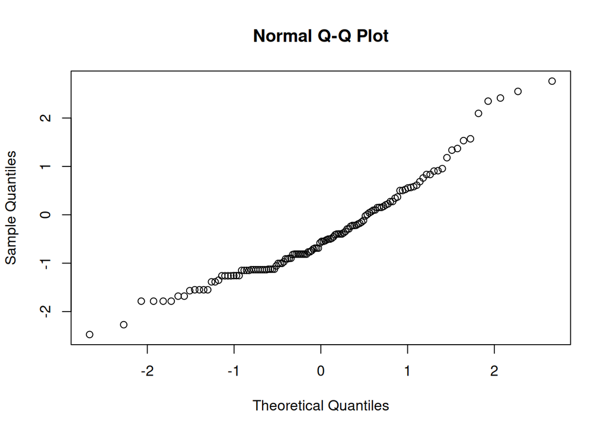

```r
qqnorm(resid(mod6))
```

```r
car::Anova(mod6)
```

```
## Analysis of Deviance Table (Type II tests)
##
## Response: April_23
##      LR Chisq Df Pr(>Chisq)
## Type    19.56  3  0.0002094 ***
## ---
## Signif. codes:  0 '***' 0.001 '**' 0.01 '*' 0.05 '.' 0.1 ' ' 1
```

```r
summary(glht(mod6 , mcp(Type="Tukey")))
```

```
##
##   Simultaneous Tests for General Linear Hypotheses
##
## Multiple Comparisons of Means: Tukey Contrasts
##
##
## Fit: glm(formula = April_23 ~ Type, family = negative.binomial(theta = mod5[["theta"]]),
##     data = April23_popsize)
##
## Linear Hypotheses:
##                          Estimate Std. Error z value Pr(>|z|)
## pavement - grass == 0      0.2553     0.3711   0.688   0.9011
## Tree bed - grass == 0      0.6560     0.4006   1.638   0.3556
## wall - grass == 0         -1.1889     0.4187  -2.840   0.0229 *
## Tree bed - pavement == 0   0.4007     0.3453   1.160   0.6504
## wall - pavement == 0      -1.4442     0.3662  -3.944   <0.001 ***
## wall - Tree bed == 0      -1.8449     0.3960  -4.659   <0.001 ***
## ---
## Signif. codes:  0 '***' 0.001 '**' 0.01 '*' 0.05 '.' 0.1 ' ' 1
## (Adjusted p values reported -- single-step method)
```

```r
leastsquare = lsmeans(mod6, pairwise ~ Type,adjust = "tukey")
cld(leastsquare)
```

```
##  Type     lsmean    SE  df asymp.LCL asymp.UCL .group
##  wall       1.91 0.293 Inf      1.34      2.49  1
##  grass      3.10 0.299 Inf      2.52      3.69   2
##  pavement   3.36 0.220 Inf      2.93      3.79   2
##  Tree bed   3.76 0.266 Inf      3.24      4.28   2
##
## Results are given on the log (not the response) scale.
## Confidence level used: 0.95
## P value adjustment: tukey method for comparing a family of 4 estimates
## significance level used: alpha = 0.05
## NOTE: If two or more means share the same grouping symbol,
##       then we cannot show them to be different.
##       But we also did not show them to be the same.
```

### Sowing 2022

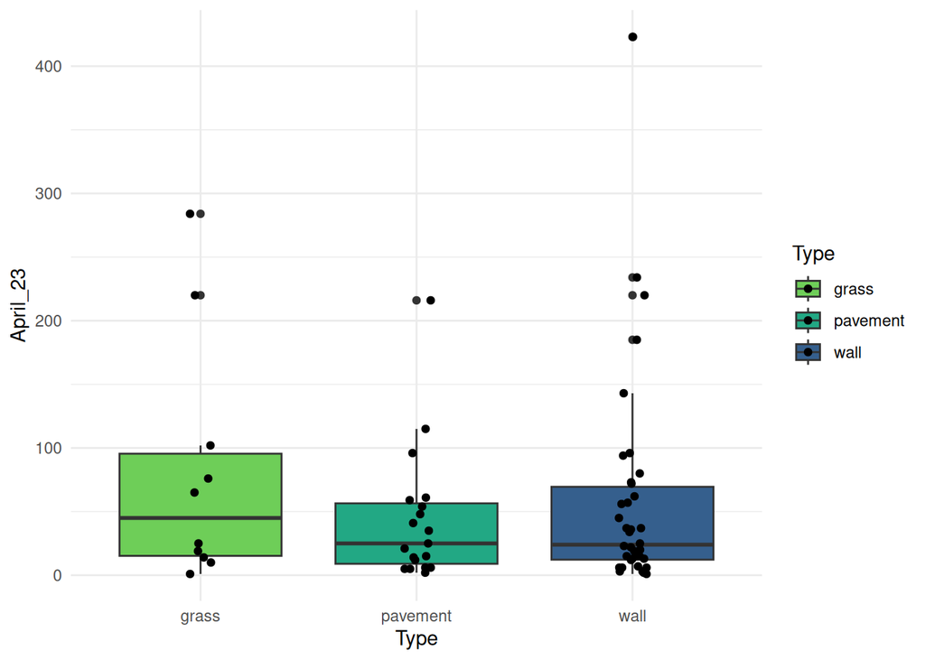

```r
data_all %>% dplyr::filter(Destroyed == "Exist"| Destroyed =="04/2024") %>%
  dplyr::filter(Sowing_1st =="07/2022") %>% dplyr::filter(Sowing_2nd =="no") %>%
  dplyr::filter(Presence_April_23 =="Yes") %>%
  dplyr::filter(Type == "grass"| Type == "pavement" | Type == "wall") %>%
  ggplot(aes(x = Type, y= April_23, fill = Type)) + geom_boxplot() + geom_point(position = position_jitterdodge())+
  theme_minimal() + scale_discrete_manual(aesthetics = "fill", values =colors)
```

#### model

```r
April23_popsize2 <- data_all %>% dplyr::filter(Destroyed == "Exist"| Destroyed =="04/2024") %>%
  dplyr::filter(Sowing_1st =="07/2022") %>% dplyr::filter(Sowing_2nd =="no") %>%
  dplyr::filter(Type == "grass"| Type == "pavement" | Type == "wall") %>%
  dplyr::filter(Presence_April_23 =="Yes")

mod5 <- MASS::glm.nb(April_23 ~ Type, data = April23_popsize2)

mod6 <- glm(April_23 ~ Type, data = April23_popsize2 ,family=negative.binomial(theta=mod5[["theta"]]))
summary(mod6)
```

```
##
## Call:
## glm(formula = April_23 ~ Type, family = negative.binomial(theta = mod5[["theta"]]),
##     data = April23_popsize2)
##
## Coefficients:
##              Estimate Std. Error t value Pr(>|t|)
## (Intercept)    4.4018     0.4249  10.361 2.56e-15 ***
## Typepavement  -0.6176     0.5256  -1.175    0.244
## Typewall      -0.3373     0.4777  -0.706    0.483
## ---
## Signif. codes:  0 '***' 0.001 '**' 0.01 '*' 0.05 '.' 0.1 ' ' 1
##
## (Dispersion parameter for Negative Binomial(0.7601) family taken to be 1.359372)
##
##     Null deviance: 80.422  on 66  degrees of freedom
## Residual deviance: 78.445  on 64  degrees of freedom
##   (1 observation deleted due to missingness)
## AIC: 678.53
##
## Number of Fisher Scoring iterations: 6
```

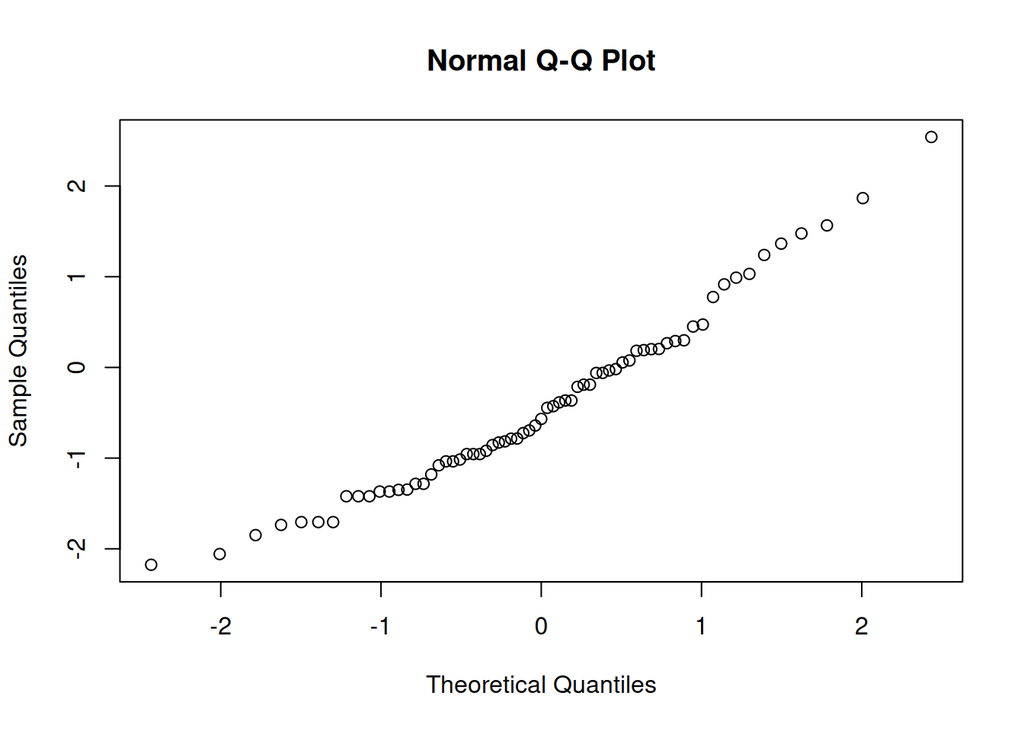

```r
qqnorm(resid(mod6))
```

```r
car::Anova(mod6)
```

```
## Analysis of Deviance Table (Type II tests)
##
## Response: April_23
##      LR Chisq Df Pr(>Chisq)
## Type   1.4539  2     0.4834
```

```r
summary(glht(mod6 , mcp(Type="Tukey")))
```

```
##
##   Simultaneous Tests for General Linear Hypotheses
##
## Multiple Comparisons of Means: Tukey Contrasts
##
##
## Fit: glm(formula = April_23 ~ Type, family = negative.binomial(theta = mod5[["theta"]]),
##     data = April23_popsize2)
##
## Linear Hypotheses:
##                       Estimate Std. Error z value Pr(>|z|)
## pavement - grass == 0  -0.6176     0.5256  -1.175    0.463
## wall - grass == 0      -0.3373     0.4777  -0.706    0.757
## wall - pavement == 0    0.2803     0.3787   0.740    0.736
## (Adjusted p values reported -- single-step method)
```

Second sowing at the first generation there is no effect of the type of habitat on the population size.

## April 2024

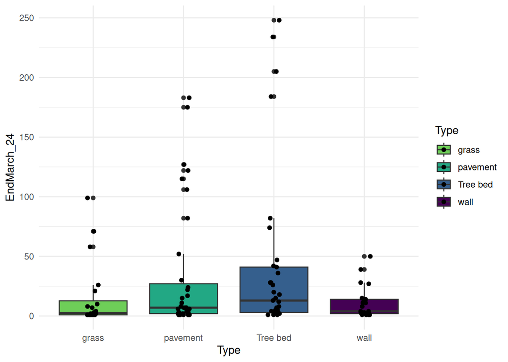

```r
data_all %>% dplyr::filter(Destroyed == "Exist") %>%
  dplyr::filter(Sowing_1st =="09/2021") %>% dplyr::filter(Sowing_2nd =="no") %>%
  dplyr::filter(Presence_April_24 =="Yes") %>% dplyr::filter(EndMarch_24 <250) %>%
  ggplot(aes(x = Type, y= EndMarch_24, fill = Type)) + geom_boxplot() + geom_point(position = position_jitterdodge())+
  theme_minimal() + scale_discrete_manual(aesthetics = "fill", values =colors)
```

#### model

Not threashold applied in the model

```r
April24_popsize <- data_all %>% dplyr::filter(Destroyed == "Exist") %>%
  dplyr::filter(Sowing_1st =="09/2021") %>% dplyr::filter(Sowing_2nd =="no") %>%
  dplyr::filter(Presence_April_24 =="Yes")

mod5 <- MASS::glm.nb(EndMarch_24 ~ Type, data = April24_popsize)

mod6 <- glm(EndMarch_24 ~ Type, data = April24_popsize ,family=negative.binomial(theta=mod5[["theta"]]))
summary(mod6)
```

```
##
## Call:
## glm(formula = EndMarch_24 ~ Type, family = negative.binomial(theta = mod5[["theta"]]),
##     data = April24_popsize)
##
## Coefficients:
##              Estimate Std. Error t value Pr(>|t|)
## (Intercept)    2.7695     0.3654   7.580 1.17e-11 ***
## Typepavement   0.7262     0.4567   1.590  0.11469
## TypeTree bed   1.4310     0.4561   3.138  0.00219 **
## Typewall      -0.3946     0.4964  -0.795  0.42842
## ---
## Signif. codes:  0 '***' 0.001 '**' 0.01 '*' 0.05 '.' 0.1 ' ' 1
##
## (Dispersion parameter for Negative Binomial(0.5073) family taken to be 1.312793)
##
##     Null deviance: 161.51  on 113  degrees of freedom
## Residual deviance: 135.89  on 110  degrees of freedom
## AIC: 964.22
##
## Number of Fisher Scoring iterations: 7
```

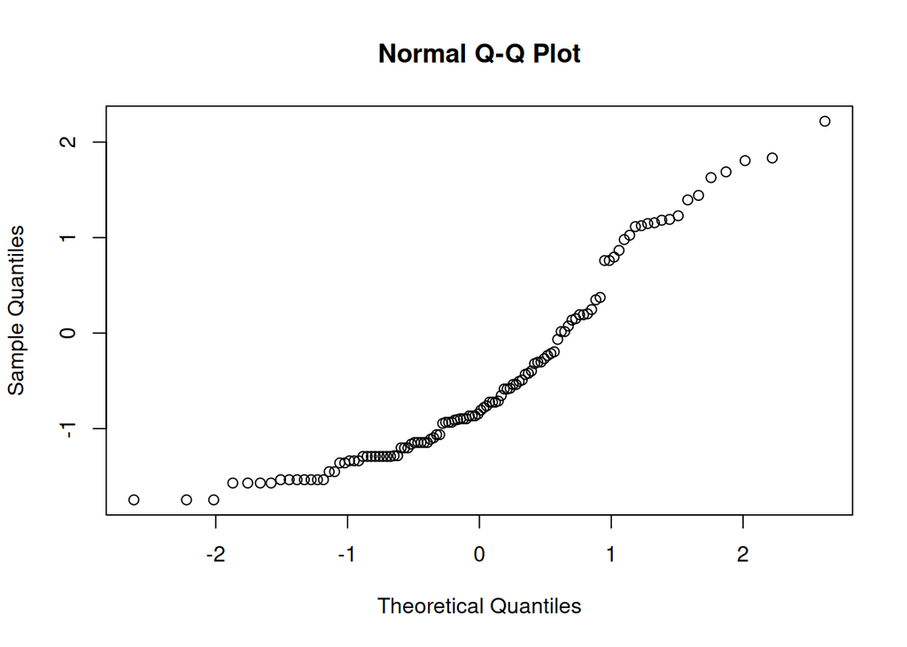

```r
qqnorm(resid(mod6))
```

```r
car::Anova(mod6)
```

```
## Analysis of Deviance Table (Type II tests)
##
## Response: EndMarch_24
##      LR Chisq Df Pr(>Chisq)
## Type   19.512  3  0.0002142 ***
## ---
## Signif. codes:  0 '***' 0.001 '**' 0.01 '*' 0.05 '.' 0.1 ' ' 1
```

```r
summary(glht(mod6 , mcp(Type="Tukey")))
```

```
##
##   Simultaneous Tests for General Linear Hypotheses
##
## Multiple Comparisons of Means: Tukey Contrasts
##
##
## Fit: glm(formula = EndMarch_24 ~ Type, family = negative.binomial(theta = mod5[["theta"]]),
##     data = April24_popsize)
##
## Linear Hypotheses:
##                          Estimate Std. Error z value Pr(>|z|)
## pavement - grass == 0      0.7262     0.4567   1.590  0.38234
## Tree bed - grass == 0      1.4310     0.4561   3.138  0.00907 **
## wall - grass == 0         -0.3946     0.4964  -0.795  0.85591
## Tree bed - pavement == 0   0.7048     0.3867   1.822  0.26106
## wall - pavement == 0      -1.1207     0.4336  -2.585  0.04789 *
## wall - Tree bed == 0      -1.8255     0.4329  -4.217  < 0.001 ***
## ---
## Signif. codes:  0 '***' 0.001 '**' 0.01 '*' 0.05 '.' 0.1 ' ' 1
## (Adjusted p values reported -- single-step method)
```

```r
leastsquare = lsmeans(mod6, pairwise ~ Type,adjust = "tukey")
cld(leastsquare)
```

```
##  Type     lsmean    SE  df asymp.LCL asymp.UCL .group
##  wall       2.37 0.336 Inf      1.72      3.03  1
##  grass      2.77 0.365 Inf      2.05      3.49  12
##  pavement   3.50 0.274 Inf      2.96      4.03   23
##  Tree bed   4.20 0.273 Inf      3.67      4.74    3
##
## Results are given on the log (not the response) scale.
## Confidence level used: 0.95
## P value adjustment: tukey method for comparing a family of 4 estimates
## significance level used: alpha = 0.05
## NOTE: If two or more means share the same grouping symbol,
##       then we cannot show them to be different.
##       But we also did not show them to be the same.
```

## Sowing 2022

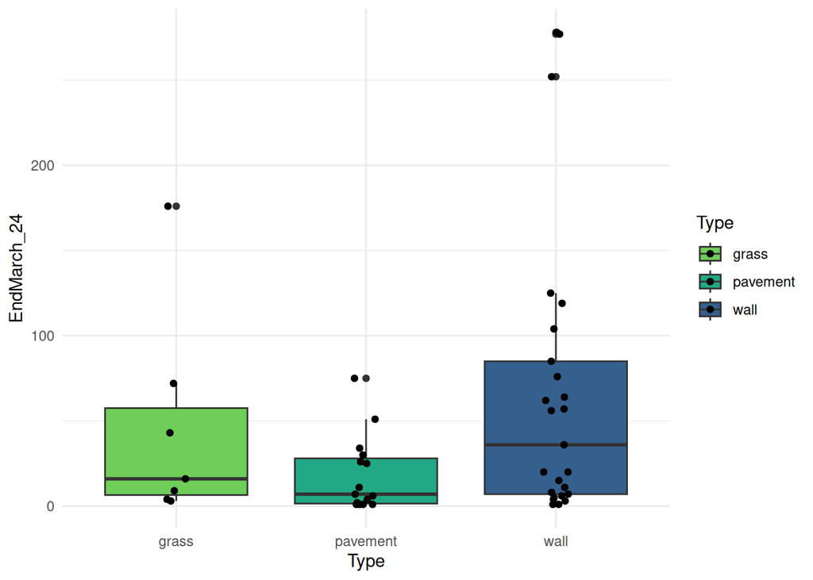

```r
data_all %>% dplyr::filter(Destroyed == "Exist"| Destroyed =="04/2024") %>%
  dplyr::filter(Sowing_1st =="07/2022") %>% dplyr::filter(Sowing_2nd =="no") %>%
  dplyr::filter(Presence_April_24 =="Yes") %>%
  ggplot(aes(x = Type, y= EndMarch_24, fill = Type)) + geom_boxplot() + geom_point(position = position_jitterdodge())+
  theme_minimal() + scale_discrete_manual(aesthetics = "fill", values =colors)
```

Not the same pattern as for the 2021 sowing, here wall have bigger population size. May be it is depending of environmental factors ?

#### model

```r
April24_popsize2 <- data_all %>% dplyr::filter(Destroyed == "Exist") %>%
  dplyr::filter(Sowing_1st =="07/2022") %>% dplyr::filter(Sowing_2nd =="no") %>%
  dplyr::filter(Presence_April_24 =="Yes")

mod5 <- MASS::glm.nb(EndMarch_24 ~ Type, data = April24_popsize2)

mod6 <- glm(EndMarch_24 ~ Type, data = April24_popsize2 ,family=negative.binomial(theta=mod5[["theta"]]))
summary(mod6)
```

```
##
## Call:
## glm(formula = EndMarch_24 ~ Type, family = negative.binomial(theta = mod5[["theta"]]),
##     data = April24_popsize2)
##
## Coefficients:
##              Estimate Std. Error t value Pr(>|t|)
## (Intercept)    3.8317     0.4727   8.107 2.84e-10 ***
## Typepavement  -0.9230     0.5744  -1.607    0.115
## Typewall       0.3830     0.5345   0.717    0.477
## ---
## Signif. codes:  0 '***' 0.001 '**' 0.01 '*' 0.05 '.' 0.1 ' ' 1
##
## (Dispersion parameter for Negative Binomial(0.6551) family taken to be 1.010204)
##
##     Null deviance: 64.027  on 46  degrees of freedom
## Residual deviance: 55.240  on 44  degrees of freedom
## AIC: 447.16
##
## Number of Fisher Scoring iterations: 6
```

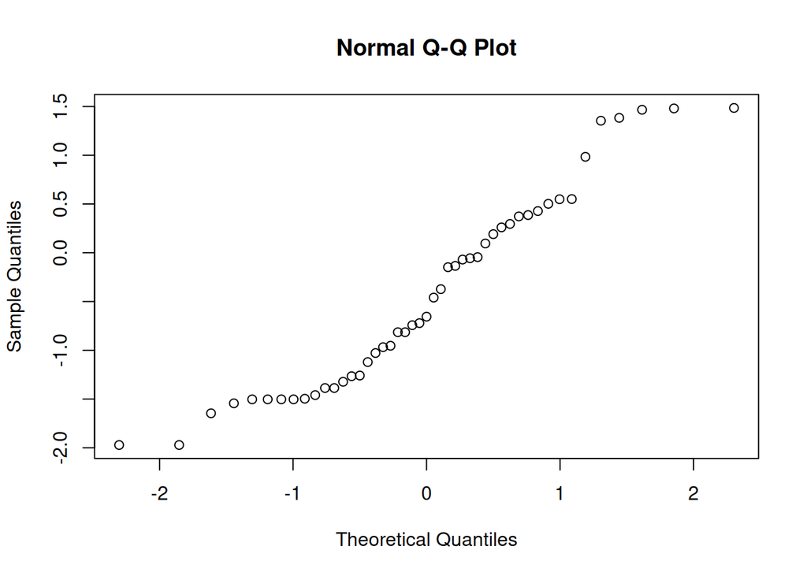

```r
qqnorm(resid(mod6))
```

```r
car::Anova(mod6)
```

```
## Analysis of Deviance Table (Type II tests)
##
## Response: EndMarch_24
##      LR Chisq Df Pr(>Chisq)
## Type   8.6982  2    0.01292 *
## ---
## Signif. codes:  0 '***' 0.001 '**' 0.01 '*' 0.05 '.' 0.1 ' ' 1
```

```r
summary(glht(mod6 , mcp(Type="Tukey")))
```

```
##
##   Simultaneous Tests for General Linear Hypotheses
##
## Multiple Comparisons of Means: Tukey Contrasts
##
##
## Fit: glm(formula = EndMarch_24 ~ Type, family = negative.binomial(theta = mod5[["theta"]]),
##     data = April24_popsize2)
##
## Linear Hypotheses:
##                       Estimate Std. Error z value Pr(>|z|)
## pavement - grass == 0  -0.9230     0.5744  -1.607  0.23866
## wall - grass == 0       0.3830     0.5345   0.717  0.75052
## wall - pavement == 0    1.3061     0.4108   3.179  0.00406 **
## ---
## Signif. codes:  0 '***' 0.001 '**' 0.01 '*' 0.05 '.' 0.1 ' ' 1
## (Adjusted p values reported -- single-step method)
```

## Over years

### Sowing 2021

Creation of a data set with all the population size by years (to take into account the destroy size)

```r
Popsize <- data.frame("Site_ID" = paste(April22_popsize$Site_ID, April22_popsize$Type, sep="_"), "Feb_22" = April22_popsize$Feb_22, "April_22" = April22_popsize$April_22, "Oct_22" = April22_popsize$October_22, "Nov_22" = April22_popsize$November_22 )
tmp <- data.frame("Site_ID" = paste(April23_popsize$Site_ID, April23_popsize$Type, sep="_"), "April_23" = April23_popsize$April_23)

Popsize <- full_join(Popsize,tmp, by = join_by(Site_ID == Site_ID))
tmp <- data.frame("Site_ID" = paste(April24_popsize$Site_ID, April24_popsize$Type, sep="_"), "EndMarch_24" = April24_popsize$EndMarch_24)
Popsize <- full_join(Popsize,tmp, by = join_by(Site_ID == Site_ID))

# rearrage the table to have all the population size in the same column
Popsize <- melt(Popsize, id.vars="Site_ID")
Popsize <- Popsize %>% separate("Site_ID", c("Site_ID", "Type"))
colnames(Popsize) <- c("Site_ID", "Type", "Time", "Nb_Idv")
```

Graphic with **no log transformation**

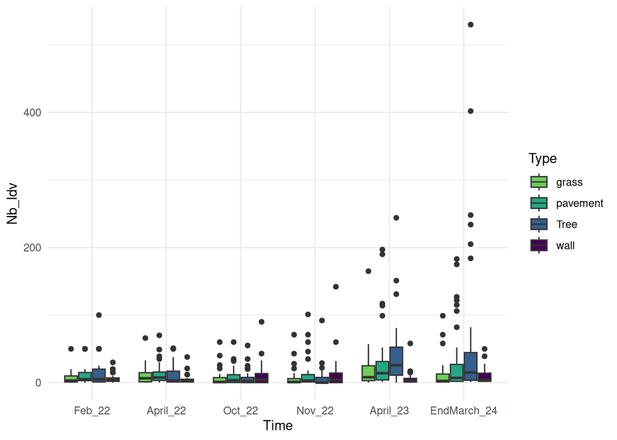

```r
ggplot(Popsize, aes(x = Time, y= Nb_Idv, fill = Type)) + geom_boxplot() +
  theme_minimal() + scale_discrete_manual(aesthetics = "fill", values =colors)
```

Graphic with **log transformation**

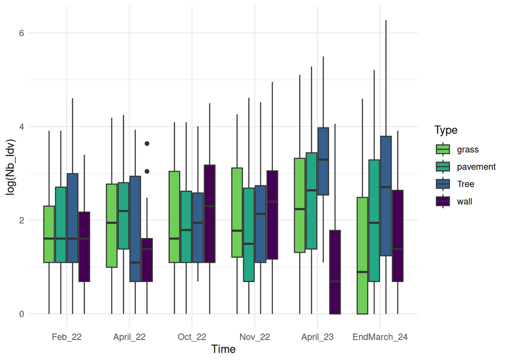

```r
ggplot(Popsize, aes(x = Time, y= log(Nb_Idv), fill = Type)) + geom_boxplot() +
  theme_minimal() + scale_discrete_manual(aesthetics = "fill", values =colors)
```

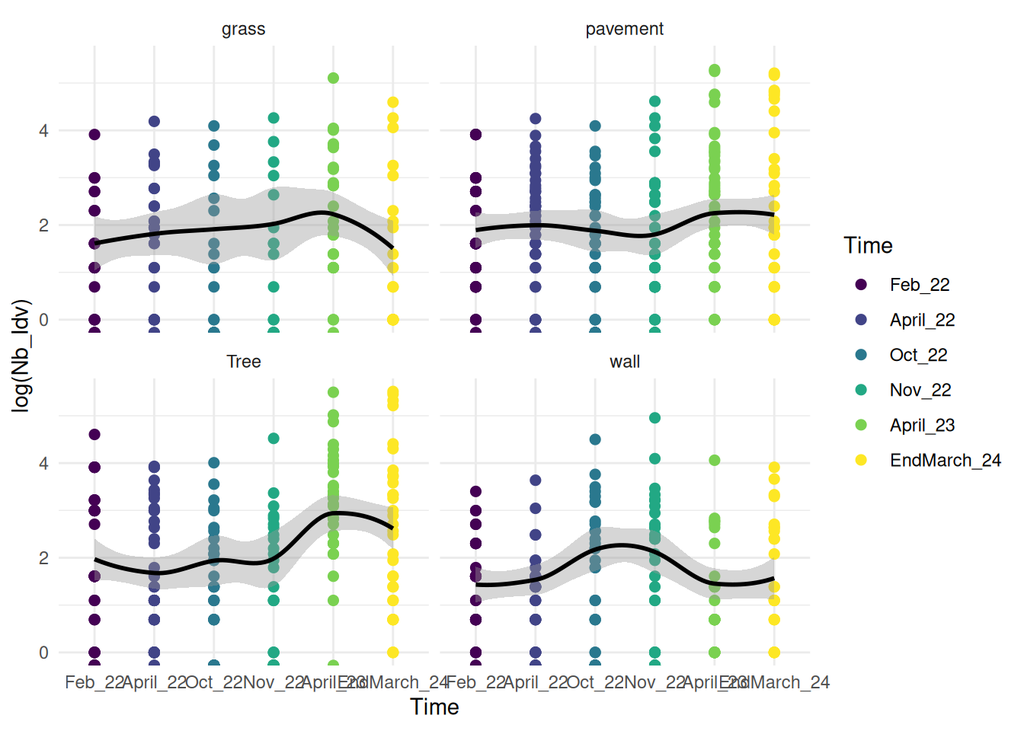

```r
Popsize %>% filter(Nb_Idv<300) %>%
  ggplot( aes(x=Time, y=log(Nb_Idv), color = Time, group=Type)) +
  geom_point(size = 2) +
  scale_color_viridis(discrete=TRUE) +
  geom_smooth(method = "loess", se = TRUE, colour= "black")+
  theme_minimal() +
  facet_wrap(~Type)
```

#### model with nested effect

```r
Popsize$Type <- as.factor(Popsize$Type)
Popsize$Time <- as.factor(Popsize$Time)

mod9 <- glm.nb(Nb_Idv ~ Type/Time, data = Popsize)

mod10 <- glm(Nb_Idv ~ Type/Time, data = Popsize ,family=negative.binomial(theta=mod9[["theta"]]))
summary(mod10)
```

```
##
## Call:
## glm(formula = Nb_Idv ~ Type/Time, family = negative.binomial(theta = mod9[["theta"]]),
##     data = Popsize)
##
## Coefficients:
##                               Estimate Std. Error t value Pr(>|t|)
## (Intercept)                   1.978345   0.315273   6.275 5.66e-10 ***
## Typepavement                  0.427424   0.392749   1.088 0.276789
## TypeTree                      0.560030   0.395503   1.416 0.157157
## Typewall                     -0.145764   0.414667  -0.352 0.725288
## Typegrass:TimeApril_22        0.443731   0.443144   1.001 0.316967
## Typepavement:TimeApril_22     0.104183   0.330852   0.315 0.752923
## TypeTree:TimeApril_22        -0.150865   0.338262  -0.446 0.655716
## Typewall:TimeApril_22        -0.298107   0.383485  -0.777 0.437170
## Typegrass:TimeOct_22          0.127907   0.459177   0.279 0.780655
## Typepavement:TimeOct_22      -0.310155   0.332587  -0.933 0.351325
## TypeTree:TimeOct_22          -0.688797   0.345153  -1.996 0.046306 *
## Typewall:TimeOct_22           0.575364   0.377673   1.523 0.128034
## Typegrass:TimeNov_22          0.194428   0.458707   0.424 0.671778
## Typepavement:TimeNov_22       0.001959   0.331217   0.006 0.995283
## TypeTree:TimeNov_22          -0.655644   0.344929  -1.901 0.057678 .
## Typewall:TimeNov_22           0.749317   0.377002   1.988 0.047192 *
## Typegrass:TimeApril_23        1.125344   0.445007   2.529 0.011631 *
## Typepavement:TimeApril_23     0.953246   0.328909   2.898 0.003853 **
## TypeTree:TimeApril_23         1.221323   0.368354   3.316 0.000955 ***
## Typewall:TimeApril_23         0.082238   0.406522   0.202 0.839735
## Typegrass:TimeEndMarch_24     0.791113   0.473095   1.672 0.094866 .
## Typepavement:TimeEndMarch_24  1.089872   0.353242   3.085 0.002102 **
## TypeTree:TimeEndMarch_24      1.662044   0.355520   4.675 3.44e-06 ***
## Typewall:TimeEndMarch_24      0.542324   0.421710   1.286 0.198802
## ---
## Signif. codes:  0 '***' 0.001 '**' 0.01 '*' 0.05 '.' 0.1 ' ' 1
##
## (Dispersion parameter for Negative Binomial(0.5265) family taken to be 1.268398)
##
##     Null deviance: 1183.47  on 841  degrees of freedom
## Residual deviance:  970.25  on 818  degrees of freedom
##   (310 observations deleted due to missingness)
## AIC: 5835.5
##
## Number of Fisher Scoring iterations: 7
```

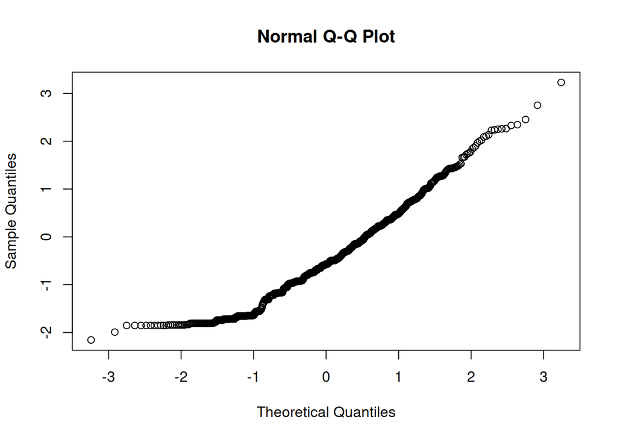

```r
qqnorm(resid(mod10))
```

```r
car::Anova(mod10)
```

```
## Analysis of Deviance Table (Type II tests)
##
## Response: Nb_Idv
##           LR Chisq Df Pr(>Chisq)
## Type        38.274  3  2.474e-08 ***
## Type:Time  129.829 20  < 2.2e-16 ***
## ---
## Signif. codes:  0 '***' 0.001 '**' 0.01 '*' 0.05 '.' 0.1 ' ' 1
```

```r
mod10_emm <- emmeans::ref_grid(mod10)
emm <- emmeans::emmeans(mod10_emm, ~ Type)
contrast(emm)
```

```
##  contrast        estimate     SE  df z.ratio p.value
##  grass effect     -0.0784 0.1100 Inf  -0.711  0.4769
##  pavement effect   0.2085 0.0894 Inf   2.332  0.0263
##  Tree effect       0.2659 0.0927 Inf   2.869  0.0082
##  wall effect      -0.3960 0.0998 Inf  -3.969  0.0003
##
## Results are averaged over the levels of: Time
## Results are given on the log (not the response) scale.
## P value adjustment: fdr method for 4 tests
```

```r
pairs(emm )
```

```
##  contrast         estimate    SE  df z.ratio p.value
##  grass - pavement  -0.2869 0.165 Inf  -1.734  0.3060
##  grass - Tree      -0.3443 0.169 Inf  -2.037  0.1744
##  grass - wall       0.3177 0.177 Inf   1.796  0.2753
##  pavement - Tree   -0.0574 0.142 Inf  -0.403  0.9778
##  pavement - wall    0.6045 0.152 Inf   3.986  0.0004
##  Tree - wall        0.6619 0.156 Inf   4.255  0.0001
##
## Results are averaged over the levels of: Time
## Results are given on the log (not the response) scale.
## P value adjustment: tukey method for comparing a family of 4 estimates
```

```r
pwpm(emm)
```

```
##            grass pavement    Tree   wall
## grass     [2.43]   0.3060  0.1744 0.2753
## pavement -0.2869   [2.71]  0.9778 0.0004
## Tree     -0.3443  -0.0574  [2.77] 0.0001
## wall      0.3177   0.6045  0.6619 [2.11]
##
## Row and column labels: Type
## Upper triangle: P values   adjust = "tukey"
## Diagonal: [Estimates] (emmean)
## Lower triangle: Comparisons (estimate)   earlier vs. later
```

Other model to take into account the emmeans warning meassage

```r
Popsize$Type <- as.factor(Popsize$Type)
Popsize$Time <- as.factor(Popsize$Time)

mod9 <- glm.nb(Nb_Idv ~ Type*Time, data = Popsize)

mod10 <- glm(Nb_Idv ~ Type*Time, data = Popsize ,family=negative.binomial(theta=mod9[["theta"]]))
summary(mod10)
```

```
##
## Call:
## glm(formula = Nb_Idv ~ Type * Time, family = negative.binomial(theta = mod9[["theta"]]),
##     data = Popsize)
##
## Coefficients:
##                              Estimate Std. Error t value Pr(>|t|)
## (Intercept)                   1.97835    0.31527   6.275 5.66e-10 ***
## Typepavement                  0.42742    0.39275   1.088   0.2768
## TypeTree                      0.56003    0.39550   1.416   0.1572
## Typewall                     -0.14576    0.41467  -0.352   0.7253
## TimeApril_22                  0.44373    0.44314   1.001   0.3170
## TimeOct_22                    0.12791    0.45918   0.279   0.7807
## TimeNov_22                    0.19443    0.45871   0.424   0.6718
## TimeApril_23                  1.12534    0.44501   2.529   0.0116 *
## TimeEndMarch_24               0.79111    0.47310   1.672   0.0949 .
## Typepavement:TimeApril_22    -0.33955    0.55303  -0.614   0.5394
## TypeTree:TimeApril_22        -0.59460    0.55749  -1.067   0.2865
## Typewall:TimeApril_22        -0.74184    0.58604  -1.266   0.2059
## Typepavement:TimeOct_22      -0.43806    0.56697  -0.773   0.4400
## TypeTree:TimeOct_22          -0.81670    0.57443  -1.422   0.1555
## Typewall:TimeOct_22           0.44746    0.59454   0.753   0.4519
## Typepavement:TimeNov_22      -0.19247    0.56579  -0.340   0.7338
## TypeTree:TimeNov_22          -0.85007    0.57392  -1.481   0.1389
## Typewall:TimeNov_22           0.55489    0.59375   0.935   0.3503
## Typepavement:TimeApril_23    -0.17210    0.55336  -0.311   0.7559
## TypeTree:TimeApril_23         0.09598    0.57768   0.166   0.8681
## Typewall:TimeApril_23        -1.04311    0.60274  -1.731   0.0839 .
## Typepavement:TimeEndMarch_24  0.29876    0.59042   0.506   0.6130
## TypeTree:TimeEndMarch_24      0.87093    0.59179   1.472   0.1415
## Typewall:TimeEndMarch_24     -0.24879    0.63377  -0.393   0.6947
## ---
## Signif. codes:  0 '***' 0.001 '**' 0.01 '*' 0.05 '.' 0.1 ' ' 1
##
## (Dispersion parameter for Negative Binomial(0.5265) family taken to be 1.268398)
##
##     Null deviance: 1183.47  on 841  degrees of freedom
## Residual deviance:  970.25  on 818  degrees of freedom
##   (310 observations deleted due to missingness)
## AIC: 5835.5
##
## Number of Fisher Scoring iterations: 7
```

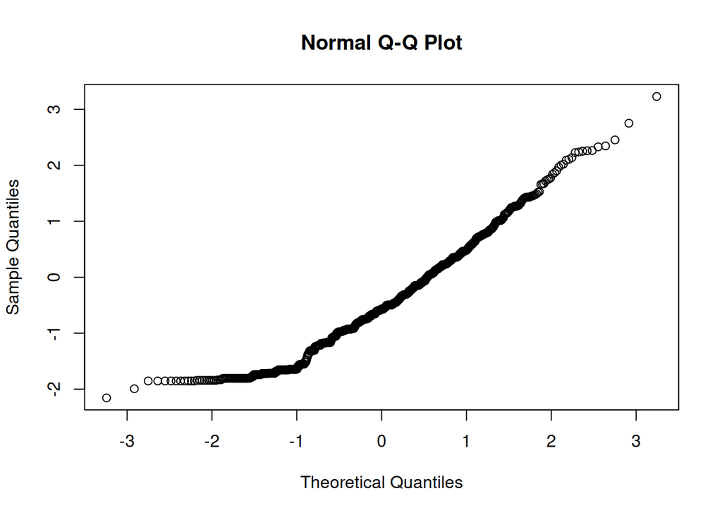

```r
qqnorm(resid(mod10))
```

```r
car::Anova(mod10)
```

```
## Analysis of Deviance Table (Type II tests)
##
## Response: Nb_Idv
##           LR Chisq Df Pr(>Chisq)
## Type        11.596  3   0.008902 **
## Time        83.750  5  < 2.2e-16 ***
## Type:Time   46.080 15  5.164e-05 ***
## ---
## Signif. codes:  0 '***' 0.001 '**' 0.01 '*' 0.05 '.' 0.1 ' ' 1
```

```r
mod10_emm <- emmeans::ref_grid(mod10)
emm <- emmeans::emmeans(mod10_emm, ~ Type |Time)
contrast(emm)
```

```
## Time = Feb_22:
##  contrast        estimate    SE  df z.ratio p.value
##  grass effect     -0.2104 0.260 Inf  -0.810  0.4178
##  pavement effect   0.2170 0.213 Inf   1.021  0.4096
##  Tree effect       0.3496 0.215 Inf   1.626  0.2508
##  wall effect      -0.3562 0.232 Inf  -1.533  0.2508
##
## Time = April_22:
##  contrast        estimate    SE  df z.ratio p.value
##  grass effect      0.2086 0.257 Inf   0.811  0.4193
##  pavement effect   0.2964 0.212 Inf   1.397  0.3248
##  Tree effect       0.1740 0.215 Inf   0.808  0.4193
##  wall effect      -0.6790 0.234 Inf  -2.896  0.0151
##
## Time = Oct_22:
##  contrast        estimate    SE  df z.ratio p.value
##  grass effect     -0.0086 0.273 Inf  -0.032  0.9749
##  pavement effect  -0.0192 0.216 Inf  -0.089  0.9749
##  Tree effect      -0.2653 0.223 Inf  -1.189  0.4688
##  wall effect       0.2931 0.232 Inf   1.264  0.4688
##
## Time = Nov_22:
##  contrast        estimate    SE  df z.ratio p.value
##  grass effect     -0.0885 0.272 Inf  -0.325  0.7451
##  pavement effect   0.1464 0.215 Inf   0.683  0.6597
##  Tree effect      -0.3786 0.223 Inf  -1.700  0.3304
##  wall effect       0.3206 0.231 Inf   1.388  0.3304
##
## Time = April_23:
##  contrast        estimate    SE  df z.ratio p.value
##  grass effect      0.0694 0.264 Inf   0.263  0.7924
##  pavement effect   0.3247 0.216 Inf   1.500  0.1782
##  Tree effect       0.7254 0.244 Inf   2.973  0.0059
##  wall effect      -1.1195 0.258 Inf  -4.339  0.0001
##
## Time = EndMarch_24:
##  contrast        estimate    SE  df z.ratio p.value
##  grass effect     -0.4406 0.292 Inf  -1.509  0.1751
##  pavement effect   0.2855 0.241 Inf   1.185  0.2359
##  Tree effect       0.9903 0.240 Inf   4.121  0.0002
##  wall effect      -0.8352 0.275 Inf  -3.035  0.0048
##
## Results are given on the log (not the response) scale.
## P value adjustment: fdr method for 4 tests
```

```r
emm <- emmeans::emmeans(mod10_emm, ~ Time|Type)
contrast(emm)
```

```
## Type = grass:
##  contrast           estimate    SE  df z.ratio p.value
##  Feb_22 effect      -0.44709 0.290 Inf  -1.542  0.3694
##  April_22 effect    -0.00336 0.287 Inf  -0.012  0.9907
##  Oct_22 effect      -0.31918 0.304 Inf  -1.052  0.4395
##  Nov_22 effect      -0.25266 0.303 Inf  -0.834  0.4853
##  April_23 effect     0.67826 0.289 Inf   2.346  0.1139
##  EndMarch_24 effect  0.34403 0.317 Inf   1.084  0.4395
##
## Type = pavement:
##  contrast           estimate    SE  df z.ratio p.value
##  Feb_22 effect      -0.30652 0.215 Inf  -1.427  0.1873
##  April_22 effect    -0.20233 0.214 Inf  -0.944  0.3452
##  Oct_22 effect      -0.61667 0.216 Inf  -2.853  0.0087
##  Nov_22 effect      -0.30456 0.215 Inf  -1.418  0.1873
##  April_23 effect     0.64673 0.212 Inf   3.046  0.0070
##  EndMarch_24 effect  0.78335 0.237 Inf   3.306  0.0057
##
## Type = Tree:
##  contrast           estimate    SE  df z.ratio p.value
##  Feb_22 effect      -0.23134 0.221 Inf  -1.048  0.2948
##  April_22 effect    -0.38221 0.221 Inf  -1.727  0.1011
##  Oct_22 effect      -0.92014 0.228 Inf  -4.030  0.0002
##  Nov_22 effect      -0.88699 0.228 Inf  -3.888  0.0002
##  April_23 effect     0.98998 0.251 Inf   3.939  0.0002
##  EndMarch_24 effect  1.43070 0.239 Inf   5.993  <.0001
##
## Type = wall:
##  contrast           estimate    SE  df z.ratio p.value
##  Feb_22 effect      -0.27519 0.249 Inf  -1.107  0.4026
##  April_22 effect    -0.57330 0.251 Inf  -2.282  0.1351
##  Oct_22 effect       0.30017 0.245 Inf   1.224  0.4026
##  Nov_22 effect       0.47413 0.245 Inf   1.938  0.1579
##  April_23 effect    -0.19295 0.274 Inf  -0.703  0.4819
##  EndMarch_24 effect  0.26713 0.289 Inf   0.924  0.4268
##
## Results are given on the log (not the response) scale.
## P value adjustment: fdr method for 6 tests
```

## From April 2022 to April 2023

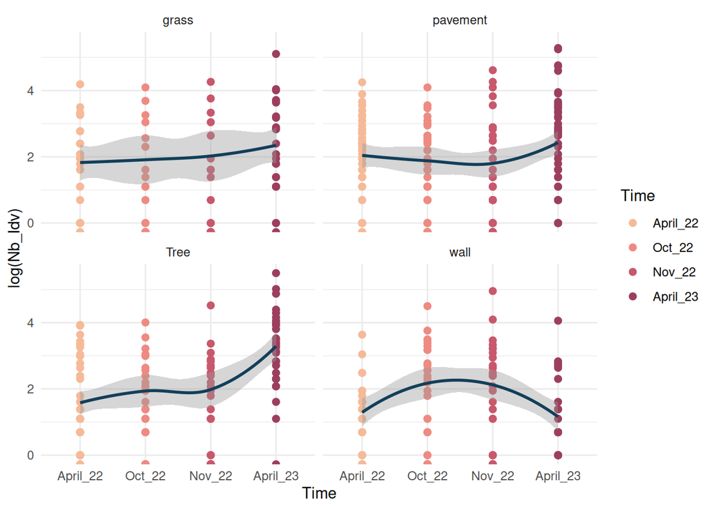

```r
Popsize %>% filter(Nb_Idv<300) %>%
  filter(Time == "April_22" |Time == "Oct_22" |Time =="Nov_22" | Time =="April_23") %>%
  ggplot( aes(x=Time, y=log(Nb_Idv), color = Time, group=Type)) +
  geom_point(size = 2) +
  scale_color_manual(values = c("#f5ba98","#ee8a82","#c8586c","#9c3f5d","#9c3f5d")) +
  geom_smooth(method = "loess", se = TRUE, colour= "#123f5a")+
  theme_minimal() +
  facet_wrap(~Type)
```

```r
#ggsave("Population_size_22-23", plot = last_plot(),dpi = 900, device = "svg")
```

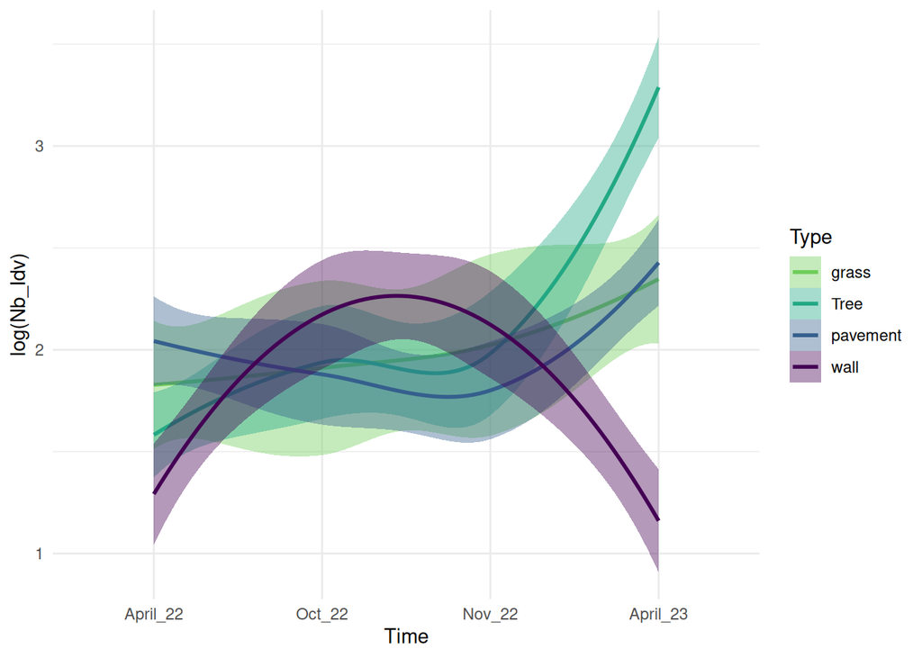

```r
# colors <- c("#6a176e","#bc3754", "#f37819", "#f8cd37")
# colors <- c("#420a68","#932667", "#dd513a", "#fca50a")
# colors <- c("#180f3d","#8c2981", "#de4968", "#fe9f6d")
# colors <- c("#482878", "#31688e", "#1f9e89", "#6ece58")
colors2 <- c("#6ece58",  "#22a884", "#355f8d", "#440154")

Popsize %>% filter(Nb_Idv<300) %>%
  filter(Time == "April_22" |Time == "Oct_22" |Time =="Nov_22" | Time =="April_23") %>%
  mutate(Type = fct_relevel(Type,
            "grass", "Tree", "pavement", "wall")) %>%
  ggplot( aes(x=Time, y=log(Nb_Idv), color = Type, group=Type, fill= Type)) +
  geom_smooth( method = "loess", se = TRUE, alpha =0.4, level = 0.75)+
  scale_color_manual(values =colors2)+
  scale_fill_manual(values =colors2)+
  theme_minimal()
```

```r
#ggsave("/home/justine/sciebo/Paper_urban_niche/Figures/Population_size_22-23_S1.svg", plot = last_plot(),dpi = 900, device = "svg", bg = "transparent")
```

```r
Popsize_2nd <- Popsize %>% filter(Time == "Oct_22" |Time =="Nov_22" | Time =="April_23")
Popsize_2nd$Type <- as.factor(Popsize_2nd$Type)
Popsize_2nd$Time <- as.factor(Popsize_2nd$Time)

mod9 <- glm.nb(Nb_Idv ~ Time*Type, data = Popsize_2nd)

mod10 <- glm(Nb_Idv ~ Time*Type, data = Popsize_2nd ,family=negative.binomial(theta=mod9[["theta"]]))
summary(mod10)
```

```
##
## Call:
## glm(formula = Nb_Idv ~ Time * Type, family = negative.binomial(theta = mod9[["theta"]]),
##     data = Popsize_2nd)
##
## Coefficients:
##                           Estimate Std. Error t value Pr(>|t|)
## (Intercept)                2.10625    0.36464   5.776 1.51e-08 ***
## TimeNov_22                 0.06652    0.51527   0.129   0.8973
## TimeApril_23               0.99744    0.50146   1.989   0.0474 *
## Typepavement              -0.01064    0.44663  -0.024   0.9810
## TypeTree                  -0.25667    0.45479  -0.564   0.5728
## Typewall                   0.30169    0.46564   0.648   0.5174
## TimeNov_22:Typepavement    0.24559    0.63059   0.389   0.6971
## TimeApril_23:Typepavement  0.26596    0.61815   0.430   0.6672
## TimeNov_22:TypeTree       -0.03337    0.64272  -0.052   0.9586
## TimeApril_23:TypeTree      0.91268    0.64810   1.408   0.1598
## TimeNov_22:Typewall        0.10743    0.65781   0.163   0.8703
## TimeApril_23:Typewall     -1.49056    0.66759  -2.233   0.0261 *
## ---
## Signif. codes:  0 '***' 0.001 '**' 0.01 '*' 0.05 '.' 0.1 ' ' 1
##
## (Dispersion parameter for Negative Binomial(0.4288) family taken to be 1.246343)
##
##     Null deviance: 552.00  on 423  degrees of freedom
## Residual deviance: 480.42  on 412  degrees of freedom
##   (152 observations deleted due to missingness)
## AIC: 2848.3
##
## Number of Fisher Scoring iterations: 7
```

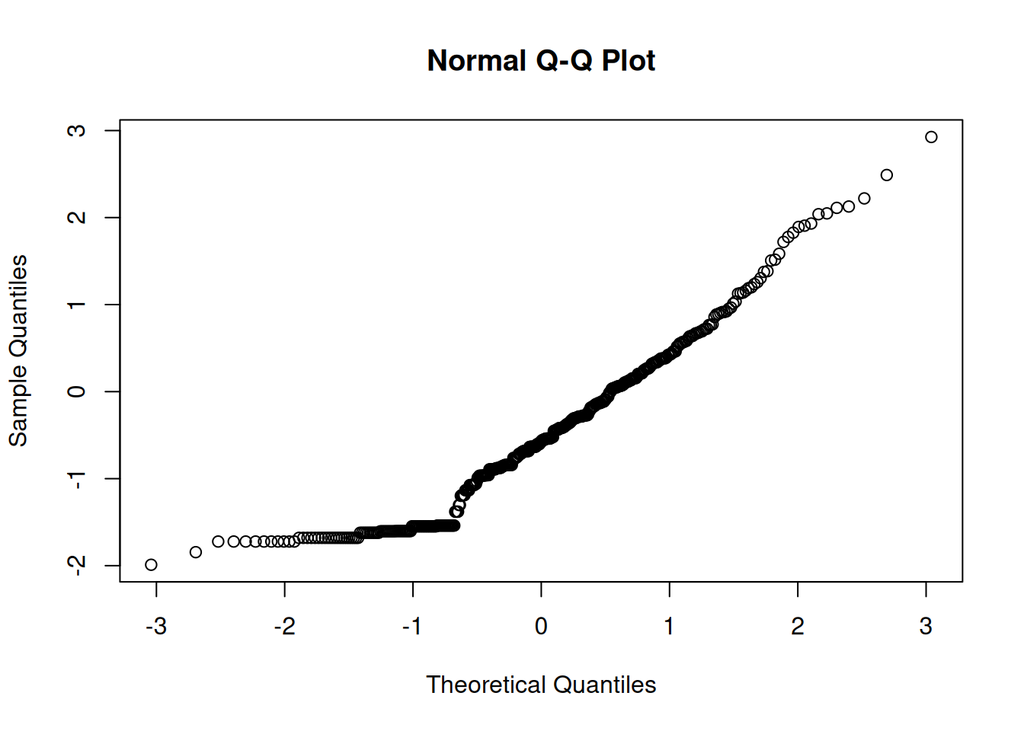

```r
qqnorm(resid(mod10))
```

```r
car::Anova(mod10)
```

```
## Analysis of Deviance Table (Type II tests)
##
## Response: Nb_Idv
##           LR Chisq Df Pr(>Chisq)
## Time        33.627  2   4.99e-08 ***
## Type         0.474  3   0.924498
## Time:Type   19.796  6   0.003011 **
## ---
## Signif. codes:  0 '***' 0.001 '**' 0.01 '*' 0.05 '.' 0.1 ' ' 1
```

```r
car::Anova(mod10, test.statistic="F")
```

```
## Analysis of Deviance Table (Type II tests)
##
## Response: Nb_Idv
## Error estimate based on Pearson residuals
##
##           Sum Sq  Df F value    Pr(>F)
## Time       41.91   2 16.8133 9.567e-08 ***
## Type        0.59   3  0.1581  0.924433
## Time:Type  24.67   6  3.2993  0.003498 **
## Residuals 513.49 412
## ---
## Signif. codes:  0 '***' 0.001 '**' 0.01 '*' 0.05 '.' 0.1 ' ' 1
```

```r
mod10_emm <- emmeans::ref_grid(mod10)
emm <- emmeans::emmeans(mod10_emm, ~ Type)
contrast(emm)
```

```
##  contrast        estimate    SE  df z.ratio p.value
##  grass effect    -0.00924 0.170 Inf  -0.054  0.9567
##  pavement effect  0.15064 0.136 Inf   1.106  0.5373
##  Tree effect      0.02719 0.145 Inf   0.187  0.9567
##  wall effect     -0.16859 0.152 Inf  -1.110  0.5373
##
## Results are averaged over the levels of: Time
## Results are given on the log (not the response) scale.
## P value adjustment: fdr method for 4 tests
```

```r
emm <- emmeans::emmeans(mod10_emm, ~ Time)
contrast(emm)
```

```
##  contrast        estimate    SE  df z.ratio p.value
##  Oct_22 effect     -0.355 0.123 Inf  -2.893  0.0057
##  Nov_22 effect     -0.209 0.123 Inf  -1.703  0.0886
##  April_23 effect    0.564 0.125 Inf   4.500  <.0001
##
## Results are averaged over the levels of: Type
## Results are given on the log (not the response) scale.
## P value adjustment: fdr method for 3 tests
```

```r
emm <- emmeans::emmeans(mod10_emm, ~ Type|Time)
contrast(emm)
```

```
## Time = Oct_22:
##  contrast        estimate    SE  df z.ratio p.value
##  grass effect     -0.0086 0.298 Inf  -0.029  0.9770
##  pavement effect  -0.0192 0.236 Inf  -0.082  0.9770
##  Tree effect      -0.2653 0.243 Inf  -1.090  0.5517
##  wall effect       0.2931 0.253 Inf   1.156  0.5517
##
## Time = Nov_22:
##  contrast        estimate    SE  df z.ratio p.value
##  grass effect     -0.0885 0.297 Inf  -0.298  0.7660
##  pavement effect   0.1464 0.235 Inf   0.624  0.7099
##  Tree effect      -0.3786 0.243 Inf  -1.558  0.4092
##  wall effect       0.3206 0.253 Inf   1.269  0.4092
##
## Time = April_23:
##  contrast        estimate    SE  df z.ratio p.value
##  grass effect      0.0694 0.289 Inf   0.240  0.8102
##  pavement effect   0.3247 0.237 Inf   1.369  0.2282
##  Tree effect       0.7254 0.268 Inf   2.711  0.0134
##  wall effect      -1.1195 0.282 Inf  -3.973  0.0003
##
## Results are given on the log (not the response) scale.
## P value adjustment: fdr method for 4 tests
```

```r
emm <- emmeans::emmeans(mod10_emm, ~ Time | Type)
contrast(emm)
```

```
## Type = grass:
##  contrast        estimate    SE  df z.ratio p.value
##  Oct_22 effect     -0.355 0.295 Inf  -1.202  0.3282
##  Nov_22 effect     -0.288 0.295 Inf  -0.978  0.3282
##  April_23 effect    0.643 0.287 Inf   2.242  0.0748
##
## Type = pavement:
##  contrast        estimate    SE  df z.ratio p.value
##  Oct_22 effect     -0.525 0.210 Inf  -2.504  0.0184
##  Nov_22 effect     -0.213 0.209 Inf  -1.019  0.3080
##  April_23 effect    0.738 0.208 Inf   3.552  0.0011
##
## Type = Tree:
##  contrast        estimate    SE  df z.ratio p.value
##  Oct_22 effect     -0.648 0.227 Inf  -2.853  0.0065
##  Nov_22 effect     -0.615 0.227 Inf  -2.708  0.0068
##  April_23 effect    1.262 0.242 Inf   5.220  <.0001
##
## Type = wall:
##  contrast        estimate    SE  df z.ratio p.value
##  Oct_22 effect      0.106 0.242 Inf   0.439  0.6608
##  Nov_22 effect      0.280 0.242 Inf   1.158  0.3704
##  April_23 effect   -0.387 0.260 Inf  -1.487  0.3704
##
## Results are given on the log (not the response) scale.
## P value adjustment: fdr method for 3 tests
```

### Sowing 2022

Creation of a data set with all the population size by years (to take into account the destroy size)

```r
Popsize2 <- data.frame("Site_ID" = paste(April23_popsize2$Site_ID, April23_popsize2$Type, sep="_"), "Oct_22" = April23_popsize2$October_22, "Nov_22" = April23_popsize2$November_22,  "April_23" = April23_popsize2$April_23 )
tmp <- data.frame("Site_ID" = paste(April24_popsize2$Site_ID, April24_popsize2$Type, sep="_"), "EndMarch_24" = April24_popsize2$EndMarch_24)

Popsize2 <- full_join(Popsize2,tmp, by = join_by(Site_ID == Site_ID))

# rearrage the table to have all the population size in the same column
Popsize2 <- melt(Popsize2, id.vars="Site_ID")
Popsize2 <- Popsize2 %>% separate("Site_ID", c("Site_ID", "Type"))
colnames(Popsize2) <- c("Site_ID", "Type", "Time", "Nb_Idv")
```

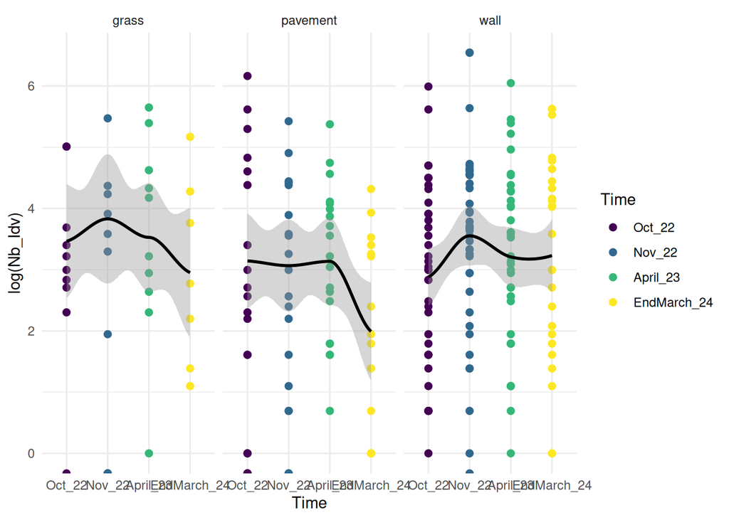

```r
Popsize2 %>%
  ggplot( aes(x=Time, y=log(Nb_Idv), color = Time, group=Type)) +
  geom_point(size = 2) +
  scale_color_viridis(discrete=TRUE) +
  geom_smooth(method = "loess", se = TRUE, colour= "black")+
  theme_minimal() +
  facet_wrap(~Type)
```

Same pattern than for the sowing 2021  
Wall and Meadow : Autumn population size > April one Pavement : Autumn pop size < April one spring recruitment but it is less visible

#### model with nested effect

```r
Popsize2$Type <- as.factor(Popsize2$Type)
Popsize2$Time <- as.factor(Popsize2$Time)

mod9 <- glm.nb(Nb_Idv ~ Type/Time, data = Popsize2)

mod10 <- glm(Nb_Idv ~ Type/Time, data = Popsize2 ,family=negative.binomial(theta=mod9[["theta"]]))
summary(mod10)
```

```
##
## Call:
## glm(formula = Nb_Idv ~ Type/Time, family = negative.binomial(theta = mod9[["theta"]]),
##     data = Popsize2)
##
## Coefficients:
##                               Estimate Std. Error t value Pr(>|t|)
## (Intercept)                   3.822098   0.472284   8.093    3e-14 ***
## Typepavement                  0.451640   0.583008   0.775  0.43930
## Typewall                      0.038361   0.529356   0.072  0.94229
## Typegrass:TimeNov_22          0.101853   0.667702   0.153  0.87889
## Typepavement:TimeNov_22      -0.507654   0.484075  -1.049  0.29538
## Typewall:TimeNov_22           0.570662   0.337671   1.690  0.09234 .
## Typegrass:TimeApril_23        0.579731   0.666963   0.869  0.38561
## Typepavement:TimeApril_23    -0.489548   0.484046  -1.011  0.31287
## Typewall:TimeApril_23         0.204058   0.340147   0.600  0.54914
## Typegrass:TimeEndMarch_24     0.009644   0.735975   0.013  0.98956
## Typepavement:TimeEndMarch_24 -1.365017   0.518083  -2.635  0.00897 **
## Typewall:TimeEndMarch_24      0.354331   0.382116   0.927  0.35472
## ---
## Signif. codes:  0 '***' 0.001 '**' 0.01 '*' 0.05 '.' 0.1 ' ' 1
##
## (Dispersion parameter for Negative Binomial(0.597) family taken to be 1.31449)
##
##     Null deviance: 317.65  on 249  degrees of freedom
## Residual deviance: 300.97  on 238  degrees of freedom
##   (22 observations deleted due to missingness)
## AIC: 2481.8
##
## Number of Fisher Scoring iterations: 7
```

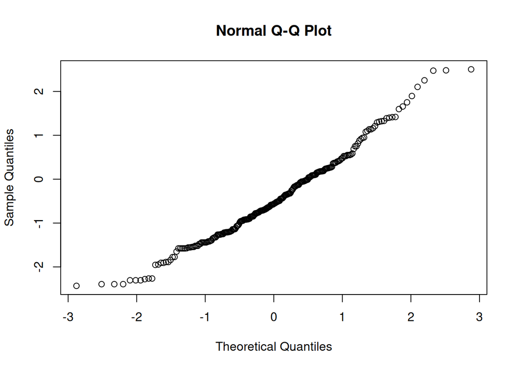

```r
qqnorm(resid(mod10))
```

```r
car::Anova(mod10)
```

```
## Analysis of Deviance Table (Type II tests)
##
## Response: Nb_Idv
##           LR Chisq Df Pr(>Chisq)
## Type        2.3306  2     0.3118
## Type:Time  10.3606  9     0.3221
```

Here I don’t have a effect of the type of habitat on the population size (same as previous) and over time neither.

```r
mod10_emm <- emmeans::ref_grid(mod10)
emm <- emmeans::emmeans(mod10_emm, ~ Type)
contrast(emm)
```

```
##  contrast        estimate    SE  df z.ratio p.value
##  grass effect      0.0546 0.181 Inf   0.302  0.7626
##  pavement effect  -0.2571 0.150 Inf  -1.708  0.1906
##  wall effect       0.2025 0.133 Inf   1.526  0.1906
##
## Results are averaged over the levels of: Time
## Results are given on the log (not the response) scale.
## P value adjustment: fdr method for 3 tests
```

```r
pairs(emm )
```

```
##  contrast         estimate    SE  df z.ratio p.value
##  grass - pavement    0.312 0.305 Inf   1.022  0.5632
##  grass - wall       -0.148 0.279 Inf  -0.529  0.8569
##  pavement - wall    -0.460 0.219 Inf  -2.102  0.0894
##
## Results are averaged over the levels of: Time
## Results are given on the log (not the response) scale.
## P value adjustment: tukey method for comparing a family of 3 estimates
```

## April 22 vs 23 vs 24

### Sowing 2021

Graphic with **log transformation**

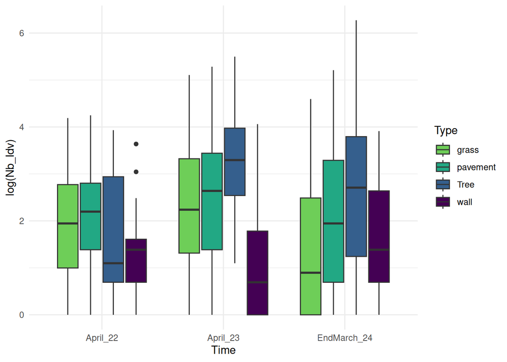

```r
Popsize <- Popsize %>% dplyr::filter(Time == "April_22" | Time == "April_23" |Time ==  "EndMarch_24")

ggplot(Popsize, aes(x = Time, y= log(Nb_Idv), fill = Type)) + geom_boxplot() +
  theme_minimal() + scale_discrete_manual(aesthetics = "fill", values =colors)
```

```r
#ggsave("Popsize_aprilS_by_Year.svg", plot = last_plot(),dpi = 300, bg = "white", scale = 2 )
```

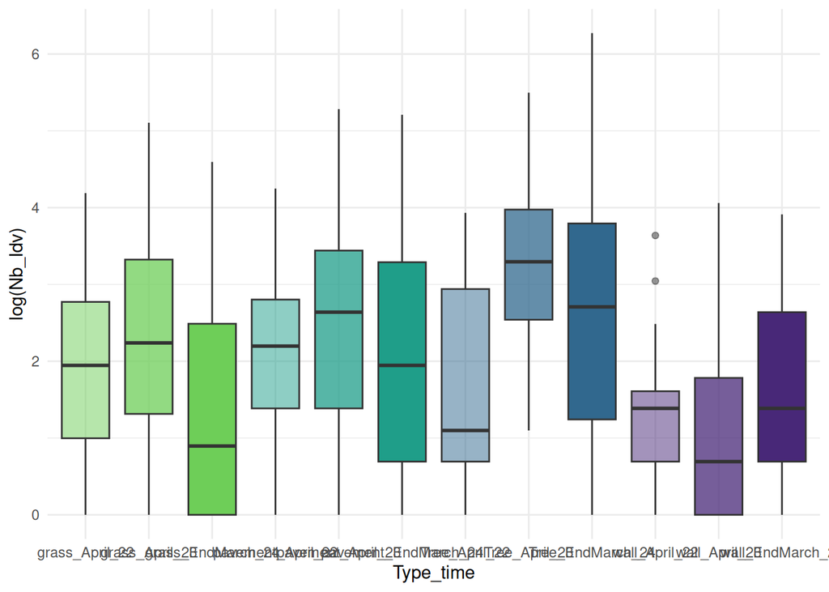

```r
Popsize$Type_time <- paste(Popsize$Type, Popsize$Time, sep = "_")

colors <- c("#6ece58", "#6ece58", "#6ece58", "#1f9e89", "#1f9e89",  "#1f9e89","#31688e","#31688e", "#31688e",  "#482878", "#482878", "#482878")
Popsize %>%
  ggplot(aes(x = Type_time ,y=log(Nb_Idv), fill = Type_time)) + geom_boxplot(aes(alpha = Time), show.legend = FALSE) +
  theme_minimal() +  scale_discrete_manual(aesthetics = "fill", values =colors)+ scale_alpha_discrete(range = c(0.5,1))
```

```r
#ggsave("Popsize_aprilS_by_Type.svg", plot = last_plot(),dpi = 300, bg = "white", scale = 2 )
```

#### model

```r
mod5 <- MASS::glm.nb(Nb_Idv ~ Type*Time, data = Popsize)

mod6 <- glm(Nb_Idv ~ Type*Time, data = Popsize ,family=negative.binomial(theta=mod5[["theta"]]))
summary(mod6)
```

```
##
## Call:
## glm(formula = Nb_Idv ~ Type * Time, family = negative.binomial(theta = mod5[["theta"]]),
##     data = Popsize)
##
## Coefficients:
##                              Estimate Std. Error t value Pr(>|t|)
## (Intercept)                   2.42208    0.29098   8.324 1.51e-15 ***
## Typepavement                  0.08788    0.36374   0.242   0.8092
## TypeTree                     -0.03457    0.36715  -0.094   0.9250
## Typewall                     -0.88760    0.38809  -2.287   0.0227 *
## TimeApril_23                  0.68161    0.41272   1.652   0.0995 .
## TimeEndMarch_24               0.34738    0.43928   0.791   0.4295
## Typepavement:TimeApril_23     0.16745    0.51404   0.326   0.7448
## TypeTree:TimeApril_23         0.69057    0.53722   1.285   0.1994
## Typewall:TimeApril_23        -0.30127    0.56370  -0.534   0.5933
## Typepavement:TimeEndMarch_24  0.63831    0.54884   1.163   0.2456
## TypeTree:TimeEndMarch_24      1.46553    0.55057   2.662   0.0081 **
## Typewall:TimeEndMarch_24      0.49305    0.59235   0.832   0.4057
## ---
## Signif. codes:  0 '***' 0.001 '**' 0.01 '*' 0.05 '.' 0.1 ' ' 1
##
## (Dispersion parameter for Negative Binomial(0.6543) family taken to be 1.361312)
##
##     Null deviance: 596.70  on 395  degrees of freedom
## Residual deviance: 454.21  on 384  degrees of freedom
##   (180 observations deleted due to missingness)
## AIC: 3047.4
##
## Number of Fisher Scoring iterations: 7
```

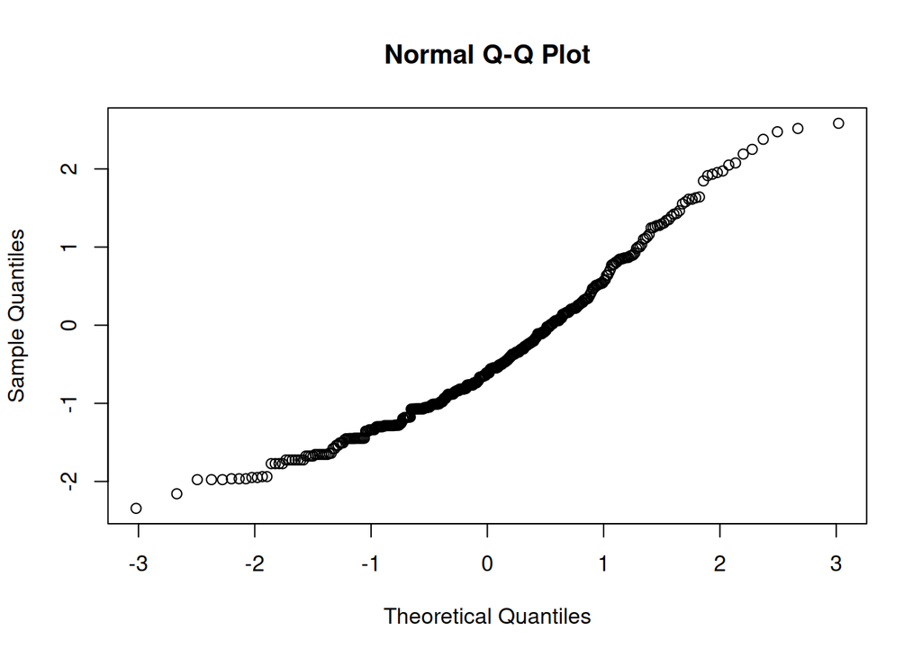

```r
qqnorm(resid(mod6))
```

```r
car::Anova(mod6)
```

```
## Analysis of Deviance Table (Type II tests)
##
## Response: Nb_Idv
##           LR Chisq Df Pr(>Chisq)
## Type        43.875  3  1.605e-09 ***
## Time        36.938  2  9.527e-09 ***
## Type:Time    9.376  6     0.1535
## ---
## Signif. codes:  0 '***' 0.001 '**' 0.01 '*' 0.05 '.' 0.1 ' ' 1
```

```r
mod6_emm <- emmeans::ref_grid(mod6)
emm <- emmeans::emmeans(mod6_emm, ~ Time | Type)
pairs(emm )
```

```
## Type = grass:
##  contrast               estimate    SE  df z.ratio p.value
##  April_22 - April_23      -0.682 0.413 Inf  -1.652  0.2242
##  April_22 - EndMarch_24   -0.347 0.439 Inf  -0.791  0.7087
##  April_23 - EndMarch_24    0.334 0.440 Inf   0.759  0.7282
##
## Type = pavement:
##  contrast               estimate    SE  df z.ratio p.value
##  April_22 - April_23      -0.849 0.306 Inf  -2.771  0.0154
##  April_22 - EndMarch_24   -0.986 0.329 Inf  -2.996  0.0077
##  April_23 - EndMarch_24   -0.137 0.327 Inf  -0.418  0.9082
##
## Type = Tree:
##  contrast               estimate    SE  df z.ratio p.value
##  April_22 - April_23      -1.372 0.344 Inf  -3.990  0.0002
##  April_22 - EndMarch_24   -1.813 0.332 Inf  -5.462  <.0001
##  April_23 - EndMarch_24   -0.441 0.358 Inf  -1.231  0.4348
##
## Type = wall:
##  contrast               estimate    SE  df z.ratio p.value
##  April_22 - April_23      -0.380 0.384 Inf  -0.991  0.5828
##  April_22 - EndMarch_24   -0.840 0.397 Inf  -2.115  0.0868
##  April_23 - EndMarch_24   -0.460 0.416 Inf  -1.105  0.5111
##
## Results are given on the log (not the response) scale.
## P value adjustment: tukey method for comparing a family of 3 estimates
```

```r
mod6_emm <- emmeans::ref_grid(mod6)
emm <- emmeans::emmeans(mod6_emm, ~ Type)
pairs(emm )
```

```
##  contrast         estimate    SE  df z.ratio p.value
##  grass - pavement   -0.356 0.219 Inf  -1.625  0.3645
##  grass - Tree       -0.684 0.225 Inf  -3.036  0.0128
##  grass - wall        0.824 0.240 Inf   3.433  0.0033
##  pavement - Tree    -0.328 0.192 Inf  -1.704  0.3215
##  pavement - wall     1.180 0.209 Inf   5.641  <.0001
##  Tree - wall         1.508 0.215 Inf   6.999  <.0001
##
## Results are averaged over the levels of: Time
## Results are given on the log (not the response) scale.
## P value adjustment: tukey method for comparing a family of 4 estimates
```

```r
mod11 <- glm.nb(Nb_Idv ~ Time/Type, data = Popsize)

mod12 <- glm(Nb_Idv ~ Time/Type, data = Popsize ,family=negative.binomial(theta=mod11[["theta"]]))
summary(mod12)
```

```
##
## Call:
## glm(formula = Nb_Idv ~ Time/Type, family = negative.binomial(theta = mod11[["theta"]]),
##     data = Popsize)
##
## Coefficients:
##                              Estimate Std. Error t value Pr(>|t|)
## (Intercept)                   2.42208    0.29098   8.324 1.51e-15 ***
## TimeApril_23                  0.68161    0.41272   1.652 0.099451 .
## TimeEndMarch_24               0.34738    0.43928   0.791 0.429549
## TimeApril_22:Typepavement     0.08788    0.36374   0.242 0.809224
## TimeApril_23:Typepavement     0.25533    0.36322   0.703 0.482510
## TimeEndMarch_24:Typepavement  0.72618    0.41100   1.767 0.078047 .
## TimeApril_22:TypeTree        -0.03457    0.36715  -0.094 0.925043
## TimeApril_23:TypeTree         0.65601    0.39218   1.673 0.095198 .
## TimeEndMarch_24:TypeTree      1.43096    0.41028   3.488 0.000543 ***
## TimeApril_22:Typewall        -0.88760    0.38809  -2.287 0.022734 *
## TimeApril_23:Typewall        -1.18887    0.40883  -2.908 0.003849 **
## TimeEndMarch_24:Typewall     -0.39455    0.44751  -0.882 0.378512
## ---
## Signif. codes:  0 '***' 0.001 '**' 0.01 '*' 0.05 '.' 0.1 ' ' 1
##
## (Dispersion parameter for Negative Binomial(0.6543) family taken to be 1.361312)
##
##     Null deviance: 596.70  on 395  degrees of freedom
## Residual deviance: 454.21  on 384  degrees of freedom
##   (180 observations deleted due to missingness)
## AIC: 3047.4
##
## Number of Fisher Scoring iterations: 7
```

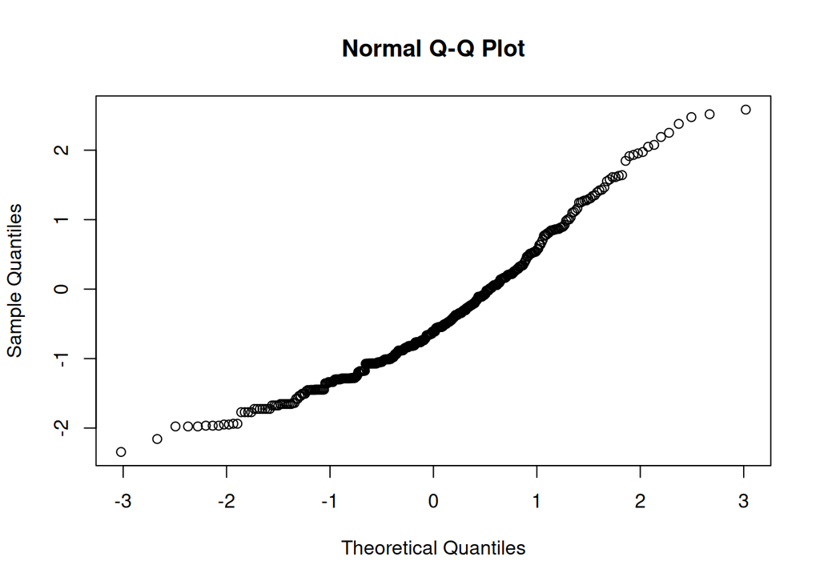

```r
qqnorm(resid(mod12))
```

```r
car::Anova(mod12)
```

```
## Analysis of Deviance Table (Type II tests)
##
## Response: Nb_Idv
##           LR Chisq Df Pr(>Chisq)
## Time        51.419  2  6.832e-12 ***
## Time:Type   53.250  9  2.621e-08 ***
## ---
## Signif. codes:  0 '***' 0.001 '**' 0.01 '*' 0.05 '.' 0.1 ' ' 1
```

```r
mod12_emm <- emmeans::ref_grid(mod12)
emm <- emmeans::emmeans(mod12_emm, ~ Time)
pairs(emm )
```

```
##  contrast               estimate    SE  df z.ratio p.value
##  April_22 - April_23      -0.821 0.182 Inf  -4.510  <.0001
##  April_22 - EndMarch_24   -0.997 0.189 Inf  -5.283  <.0001
##  April_23 - EndMarch_24   -0.176 0.194 Inf  -0.906  0.6365
##
## Results are averaged over the levels of: Type
## Results are given on the log (not the response) scale.
## P value adjustment: tukey method for comparing a family of 3 estimates
```

```r
mod12_emm <- emmeans::ref_grid(mod12)
emm <- emmeans::emmeans(mod12_emm, ~ Type)
pairs(emm )
```

```
##  contrast                                 estimate    SE  df z.ratio p.value
##  grass April_22 - pavement April_22        -0.0879 0.364 Inf  -0.242  1.0000
##  grass April_22 - Tree April_22             0.0346 0.367 Inf   0.094  1.0000
##  grass April_22 - wall April_22             0.8876 0.388 Inf   2.287  0.4858
##  grass April_22 - grass April_23           -0.6816 0.413 Inf  -1.652  0.8897
##  grass April_22 - pavement April_23        -0.9369 0.362 Inf  -2.589  0.2855
##  grass April_22 - Tree April_23            -1.3376 0.391 Inf  -3.422  0.0306
##  grass April_22 - wall April_23             0.5073 0.408 Inf   1.244  0.9853
##  grass April_22 - grass EndMarch_24        -0.3474 0.439 Inf  -0.791  0.9997
##  grass April_22 - pavement EndMarch_24     -1.0736 0.381 Inf  -2.816  0.1728
##  grass April_22 - Tree EndMarch_24         -1.7783 0.380 Inf  -4.675  0.0002
##  grass April_22 - wall EndMarch_24          0.0472 0.420 Inf   0.112  1.0000
##  pavement April_22 - Tree April_22          0.1224 0.313 Inf   0.392  1.0000
##  pavement April_22 - wall April_22          0.9755 0.337 Inf   2.894  0.1427
##  pavement April_22 - grass April_23        -0.5937 0.365 Inf  -1.626  0.8998
##  pavement April_22 - pavement April_23     -0.8491 0.306 Inf  -2.771  0.1925
##  pavement April_22 - Tree April_23         -1.2497 0.340 Inf  -3.673  0.0128
##  pavement April_22 - wall April_23          0.5951 0.359 Inf   1.656  0.8878
##  pavement April_22 - grass EndMarch_24     -0.2595 0.395 Inf  -0.657  1.0000
##  pavement April_22 - pavement EndMarch_24  -0.9857 0.329 Inf  -2.996  0.1096
##  pavement April_22 - Tree EndMarch_24      -1.6905 0.328 Inf  -5.152  <.0001
##  pavement April_22 - wall EndMarch_24       0.1350 0.374 Inf   0.361  1.0000
##  Tree April_22 - wall April_22              0.8530 0.341 Inf   2.504  0.3373
##  Tree April_22 - grass April_23            -0.7162 0.369 Inf  -1.943  0.7317
##  Tree April_22 - pavement April_23         -0.9715 0.310 Inf  -3.129  0.0756
##  Tree April_22 - Tree April_23             -1.3722 0.344 Inf  -3.990  0.0038
##  Tree April_22 - wall April_23              0.4727 0.363 Inf   1.303  0.9790
##  Tree April_22 - grass EndMarch_24         -0.3819 0.398 Inf  -0.960  0.9984
##  Tree April_22 - pavement EndMarch_24      -1.1081 0.333 Inf  -3.330  0.0412
##  Tree April_22 - Tree EndMarch_24          -1.8129 0.332 Inf  -5.462  <.0001
##  Tree April_22 - wall EndMarch_24           0.0126 0.377 Inf   0.033  1.0000
##  wall April_22 - grass April_23            -1.5692 0.389 Inf  -4.030  0.0032
##  wall April_22 - pavement April_23         -1.8245 0.335 Inf  -5.447  <.0001
##  wall April_22 - Tree April_23             -2.2252 0.366 Inf  -6.077  <.0001
##  wall April_22 - wall April_23             -0.3803 0.384 Inf  -0.991  0.9979
##  wall April_22 - grass EndMarch_24         -1.2350 0.417 Inf  -2.959  0.1210
##  wall April_22 - pavement EndMarch_24      -1.9612 0.356 Inf  -5.512  <.0001
##  wall April_22 - Tree EndMarch_24          -2.6659 0.355 Inf  -7.511  <.0001
##  wall April_22 - wall EndMarch_24          -0.8404 0.397 Inf  -2.115  0.6120
##  grass April_23 - pavement April_23        -0.2553 0.363 Inf  -0.703  0.9999
```

[output cut: 15 more lines]

```
##  Tree April_23 - Tree EndMarch_24          -0.4407 0.358 Inf  -1.231  0.9866
##  Tree April_23 - wall EndMarch_24           1.3848 0.400 Inf   3.461  0.0269
##  wall April_23 - grass EndMarch_24         -0.8546 0.436 Inf  -1.962  0.7195
##  wall April_23 - pavement EndMarch_24      -1.5808 0.377 Inf  -4.194  0.0016
##  wall April_23 - Tree EndMarch_24          -2.2856 0.376 Inf  -6.076  <.0001
##  wall April_23 - wall EndMarch_24          -0.4601 0.416 Inf  -1.105  0.9946
##  grass EndMarch_24 - pavement EndMarch_24  -0.7262 0.411 Inf  -1.767  0.8361
##  grass EndMarch_24 - Tree EndMarch_24      -1.4310 0.410 Inf  -3.488  0.0246
##  grass EndMarch_24 - wall EndMarch_24       0.3946 0.448 Inf   0.882  0.9993
##  pavement EndMarch_24 - Tree EndMarch_24   -0.7048 0.347 Inf  -2.029  0.6735
##  pavement EndMarch_24 - wall EndMarch_24    1.1207 0.391 Inf   2.869  0.1520
##  Tree EndMarch_24 - wall EndMarch_24        1.8255 0.390 Inf   4.682  0.0002
##
## Results are given on the log (not the response) scale.
## P value adjustment: tukey method for comparing a family of 12 estimates
```

```r
mod12_emm <- emmeans::ref_grid(mod12)
emm <- emmeans::emmeans(mod12_emm, ~ Type, by="Time")
pairs(emm )
```

```
## Time = April_22:
##  contrast         estimate    SE  df z.ratio p.value
##  grass - pavement  -0.0879 0.364 Inf  -0.242  1.0000
##  grass - Tree       0.0346 0.367 Inf   0.094  1.0000
##  grass - wall       0.8876 0.388 Inf   2.287  0.6930
##  pavement - Tree    0.1224 0.313 Inf   0.392  1.0000
##  pavement - wall    0.9755 0.337 Inf   2.894  0.2554
##  Tree - wall        0.8530 0.341 Inf   2.504  0.5273
##
## Time = April_23:
##  contrast         estimate    SE  df z.ratio p.value
##  grass - pavement  -0.2553 0.363 Inf  -0.703  1.0000
##  grass - Tree      -0.6560 0.392 Inf  -1.673  0.9717
##  grass - wall       1.1889 0.409 Inf   2.908  0.2478
##  pavement - Tree   -0.4007 0.338 Inf  -1.185  0.9995
##  pavement - wall    1.4442 0.357 Inf   4.041  0.0068
##  Tree - wall        1.8449 0.387 Inf   4.770  0.0003
##
## Time = EndMarch_24:
##  contrast         estimate    SE  df z.ratio p.value
##  grass - pavement  -0.7262 0.411 Inf  -1.767  0.9528
##  grass - Tree      -1.4310 0.410 Inf  -3.488  0.0501
##  grass - wall       0.3946 0.448 Inf   0.882  1.0000
##  pavement - Tree   -0.7048 0.347 Inf  -2.029  0.8555
##  pavement - wall    1.1207 0.391 Inf   2.869  0.2701
##  Tree - wall        1.8255 0.390 Inf   4.682  0.0004
##
## Results are given on the log (not the response) scale.
## P value adjustment: tukey method for comparing a family of 18 estimates
```

### Sowing 2022

Graphic with **log transformation**

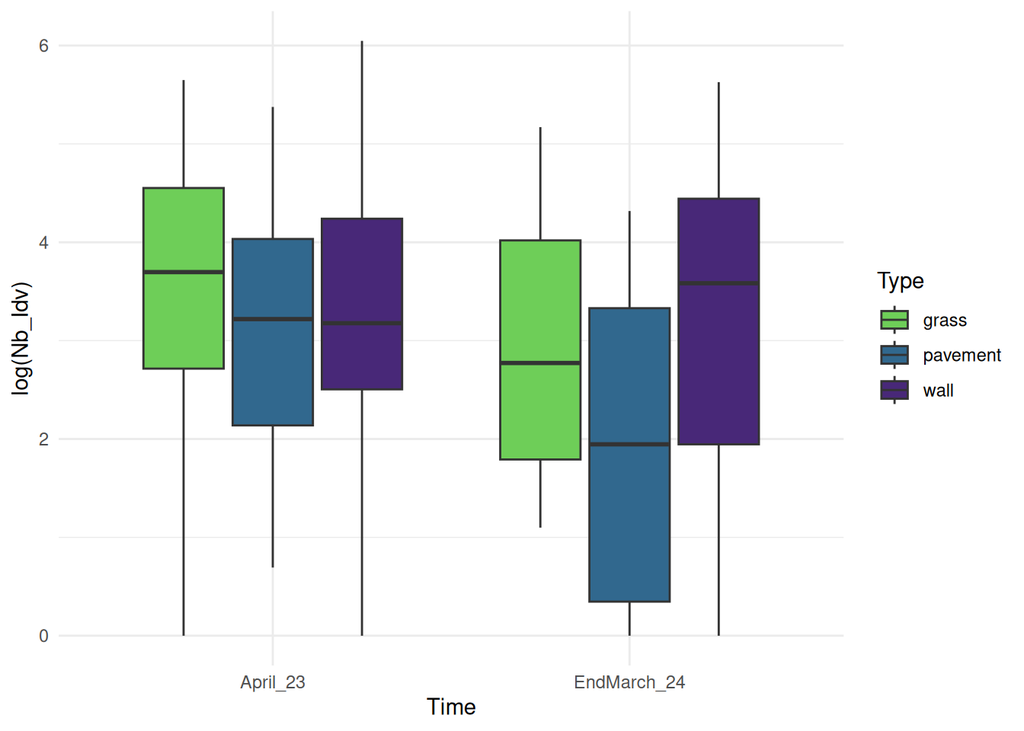

```r
Popsize2 <- Popsize2 %>% dplyr::filter(Time == "April_23" |Time ==  "EndMarch_24")

colors <- c( "#6ece58","#31688e","#482878")
ggplot(Popsize2, aes(x = Time, y= log(Nb_Idv), fill = Type)) + geom_boxplot() +
  theme_minimal() + scale_discrete_manual(aesthetics = "fill", values =colors)
```

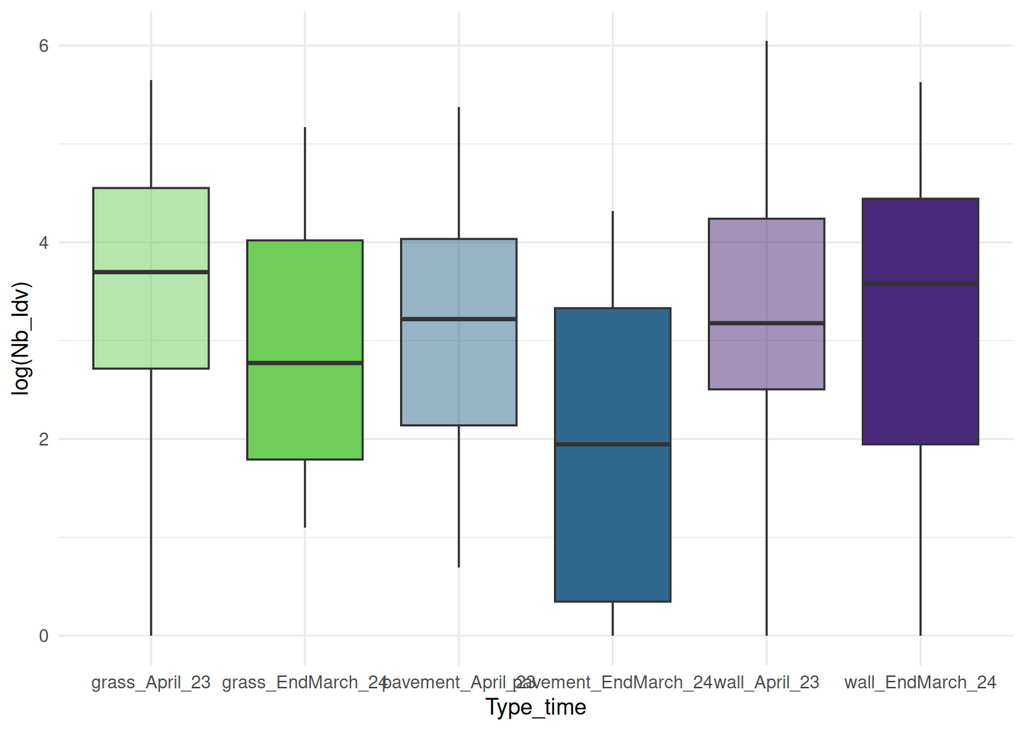

```r
Popsize2$Type_time <- paste(Popsize2$Type, Popsize2$Time, sep = "_")

colors <- c ("#6ece58", "#6ece58", "#31688e", "#31688e","#482878", "#482878")
Popsize2 %>%
  ggplot(aes(x = Type_time ,y=log(Nb_Idv), fill = Type_time)) + geom_boxplot(aes(alpha = Time), show.legend = FALSE) +
  theme_minimal() +  scale_discrete_manual(aesthetics = "fill", values =colors)+ scale_alpha_discrete(range = c(0.5,1))
```

#### model

```r
mod5 <- MASS::glm.nb(Nb_Idv ~ Type*Time, data = Popsize2)

mod6 <- glm(Nb_Idv ~ Type*Time, data = Popsize2 ,family=negative.binomial(theta=mod5[["theta"]]))
summary(mod6)
```

```
##
## Call:
## glm(formula = Nb_Idv ~ Type * Time, family = negative.binomial(theta = mod5[["theta"]]),
##     data = Popsize2)
##
## Coefficients:
##                              Estimate Std. Error t value Pr(>|t|)
## (Intercept)                    4.4018     0.4126  10.668   <2e-16 ***
## Typepavement                  -0.6176     0.5104  -1.210    0.229
## Typewall                      -0.3373     0.4639  -0.727    0.469
## TimeEndMarch_24               -0.5701     0.6443  -0.885    0.378
## Typepavement:TimeEndMarch_24  -0.3054     0.7889  -0.387    0.699
## Typewall:TimeEndMarch_24       0.7204     0.7268   0.991    0.324
## ---
## Signif. codes:  0 '***' 0.001 '**' 0.01 '*' 0.05 '.' 0.1 ' ' 1
##
## (Dispersion parameter for Negative Binomial(0.7138) family taken to be 1.204806)
##
##     Null deviance: 145.71  on 113  degrees of freedom
## Residual deviance: 133.75  on 108  degrees of freedom
##   (22 observations deleted due to missingness)
## AIC: 1126.1
##
## Number of Fisher Scoring iterations: 6
```

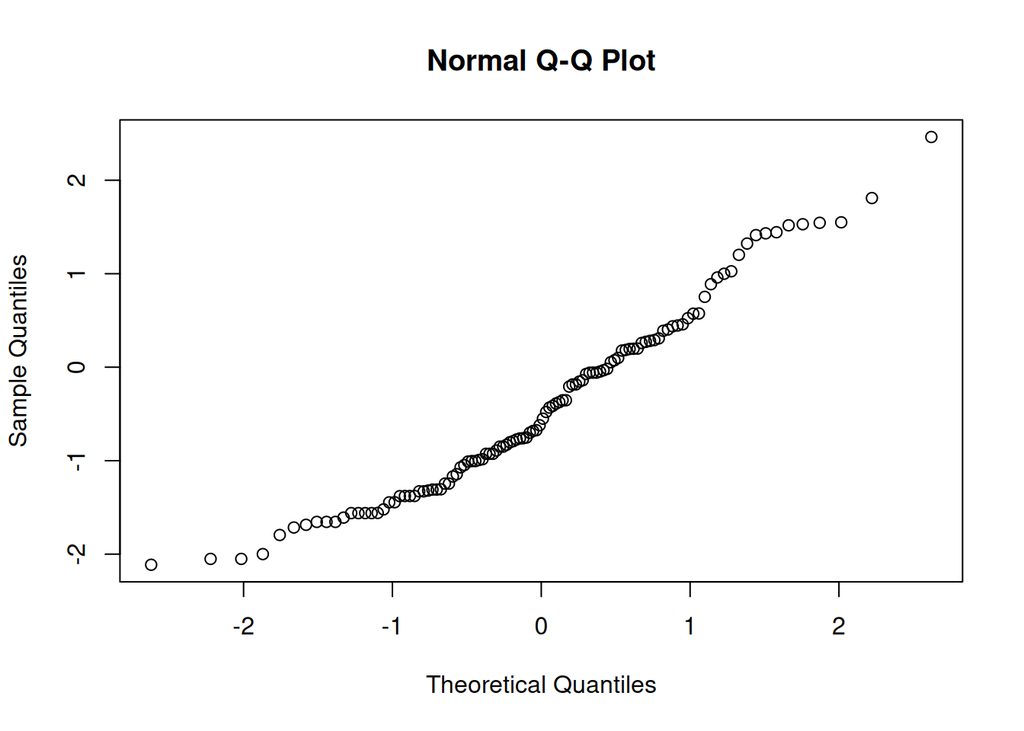

```r
qqnorm(resid(mod6))
```

```r
car::Anova(mod6)
```

```
## Analysis of Deviance Table (Type II tests)
##
## Response: Nb_Idv
##           LR Chisq Df Pr(>Chisq)
## Type        5.9699  2    0.05054 .
## Time        0.9317  1    0.33443
## Type:Time   3.5058  2    0.17327
## ---
## Signif. codes:  0 '***' 0.001 '**' 0.01 '*' 0.05 '.' 0.1 ' ' 1
```

```r
mod11 <- glm.nb(Nb_Idv ~ Time*Type, data = Popsize2)

mod12 <- glm(Nb_Idv ~ Time*Type, data = Popsize2 ,family=negative.binomial(theta=mod11[["theta"]]))
summary(mod12)
```

```
##
## Call:
## glm(formula = Nb_Idv ~ Time * Type, family = negative.binomial(theta = mod11[["theta"]]),
##     data = Popsize2)
##
## Coefficients:
##                              Estimate Std. Error t value Pr(>|t|)
## (Intercept)                    4.4018     0.4126  10.668   <2e-16 ***
## TimeEndMarch_24               -0.5701     0.6443  -0.885    0.378
## Typepavement                  -0.6176     0.5104  -1.210    0.229
## Typewall                      -0.3373     0.4639  -0.727    0.469
## TimeEndMarch_24:Typepavement  -0.3054     0.7889  -0.387    0.699
## TimeEndMarch_24:Typewall       0.7204     0.7268   0.991    0.324
## ---
## Signif. codes:  0 '***' 0.001 '**' 0.01 '*' 0.05 '.' 0.1 ' ' 1
##
## (Dispersion parameter for Negative Binomial(0.7138) family taken to be 1.204806)
##
##     Null deviance: 145.71  on 113  degrees of freedom
## Residual deviance: 133.75  on 108  degrees of freedom
##   (22 observations deleted due to missingness)
## AIC: 1126.1
##
## Number of Fisher Scoring iterations: 6
```

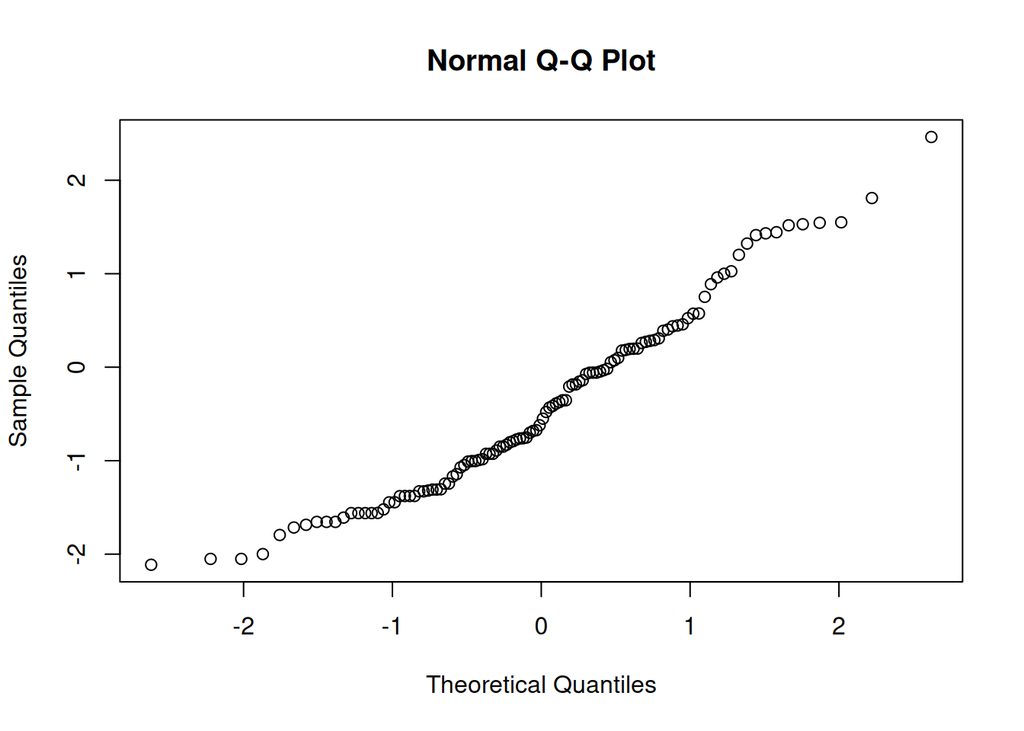

```r
qqnorm(resid(mod12))
```

```r
car::Anova(mod12)
```

```
## Analysis of Deviance Table (Type II tests)
##
## Response: Nb_Idv
##           LR Chisq Df Pr(>Chisq)
## Time        0.9317  1    0.33443
## Type        5.9699  2    0.05054 .
## Time:Type   3.5058  2    0.17327
## ---
## Signif. codes:  0 '***' 0.001 '**' 0.01 '*' 0.05 '.' 0.1 ' ' 1
```

```r
mod12_emm <- emmeans::ref_grid(mod12)
emm <- emmeans::emmeans(mod12_emm, ~ Time|Type)
pairs(emm )
```

```
## Type = grass:
##  contrast               estimate    SE  df z.ratio p.value
##  April_23 - EndMarch_24    0.570 0.644 Inf   0.885  0.3763
##
## Type = pavement:
##  contrast               estimate    SE  df z.ratio p.value
##  April_23 - EndMarch_24    0.875 0.455 Inf   1.923  0.0544
##
## Type = wall:
##  contrast               estimate    SE  df z.ratio p.value
##  April_23 - EndMarch_24   -0.150 0.336 Inf  -0.447  0.6551
##
## Results are given on the log (not the response) scale.
```